# ELE225 Probability and Statistics Notes (For Semester 1, Weeks 1-5)

# 1 Set Theory, Events and Probability

Probability theory gives us a rigorous mathematical model for explaining chance phenomena observed in the real world. It may not describe reality perfectly, but it can still be extremely useful.

## 1.1 Motivation

We regularly have to make decisions in day to day life based upon the potential outcomes of that decision. We do this by weighing up the probabilities of the different outcomes.

- A doctor is treating a patient, and is considering whether to prescribe a particular drug. How likely is it that the drug will cure the patient?
- A probation board is considering whether to release a prisoner early on parole. How likely is the prisoner to re-offend?
- A bank is considering whether to approve a loan. How likely is it that the loan will be repaid?
- A government is considering a CO${}_2$ emissions target. What would the effect of a 20% cut in emissions be on global mean temperatures in 20 years’ time?

Consider the following example.

- You are being tested for a disease.
- The disease is “rare”.
- The test is not perfect. You are told:
  - If you **have** the disease, the test will “almost certainly” detect it.
  - If you **don’t have** the disease, there is “a small chance” the test will mistakenly report that you have it
- Say the test result is positive.
- How certain are you that you really have the disease?

You may have seen a definition of probability like this:

Suppose all the outcomes in an experiment are equally likely. The probability of an event $A$ is defined to be
$$\begin{equation}
P(A)=\frac{\mbox{number of outcomes in which $A$ occurs}}{\mbox{total number of possible outcomes}} \tag{1.1}
\end{equation}$$

**Example 1.1** A deck of 52 playing cards is shuffled thoroughly. What is the probability that the top card is an ace?

Solution:

After a shuffle that results in a random deck then there are only four options of the 52 in which an Ace would be on the top; the answer is therefore $\frac{4}{52}=\frac{1}{13}$.

We need to extend this definition of probability since it is limited use. We begin by making some definitions and defining terminology.

## 1.2 Set theory

We consider **experiments**, which here means observing something **in the future**. To consider how likely some particular outcome is to occur we first have to consider all possible outcomes of the experiment. We use a **set** to list all the possible outcomes.

**Definition 1.1** A **sample space** $S$ is a set which lists **all** the possible outcomes of an ‘experiment’.

Note that
$$\{1,2,3\}=\{1,3,2\}=...=\{3,2,1\}$$
i.e. the order of the elements in the set is not important.

**Example 1.2** If we flip a coin and get $\{H,T\}$ and also pick a random letter from $\{A,B,C,D\}$. Give all the members of the sample space $S$ of the form $(\text{coin flip},\text{letter})$.

Solution:

$S=\{(\text{H},\text{A}),(\text{H},\text{B}),(\text{H},\text{C}),(\text{H},\text{D}),(\text{T},\text{A}),(\text{T},\text{B}),(\text{T},\text{C}),(\text{T},\text{D})\}$.

**Definition 1.2** If $A$ and $B$ are two sets then we say that $A$ is a subset of $B$ if every element of set $A$ is also in set $B$. This is written as $A\subseteq B$ or $A\subset B$, where the former allows equality of the sets, and the latter doesn`t (this is analogous to the difference between $\leq$ and $<$).

**Definition 1.3** An **event** is a subset of a sample space.

**Example 1.3** Two six sided dice are rolled simultaneously. State the sample space of the experiment. Use Equation (1.1) to calculate the probability that the sum of the numbers showing on the dice is five.

Solution:

The sample space is the set of all pairs $(X,Y)$, where $X$ is the value on the first die and $Y$ is the value on the second die: $S=\{(1,1),(1,2),\dots,(6,6)\}$. There are $36$ potential outcomes of the throw. The event $A$ is the set $(X,Y)$ such that $X+Y=5$. Therefore $A=\{(1,4),(2,3),(3,2),(4,1)\}$ and
$$P(X+Y=5)=\frac{\text{Number of elements in A}}{\text{Number of elements in S}}=\frac{4}{36}=\frac{1}{9}.$$

Given a sample space $S$ and two subsets (or events) $A$ and $B$, the set operations **union**, **intersection**, **complement** and **difference** all define further events.

The **union** $A\cup B$ corresponds to either $A$ occurring *or* to $B$ occurring *or* to both occurring. We can visualise this using a *Venn diagram* (see Figure 1.1). The rectangle represents the sample space $S$, the two circles represent the subsets $A$ and $B$, and the shaded area represents the set $A\cup B$.

[figure not shown]

Figure 1.1: A Venn diagram, with the shaded region showing the union of $A$ and $B$.

The **intersection** $A \cap B$ corresponds to both $A$ and $B$ occurring. See Figure 1.2

[figure not shown]

Figure 1.2: A Venn diagram, with the shaded region showing the intersection of $A$ and $B$.

If there are no elements that are both in $A$ and in $B$, then $A\cap B = \varnothing$ where $\varnothing$ is the empty set. In this case we say that $A$ and $B$ are **mutually exclusive**. See Figure 1.3

[figure not shown]

Figure 1.3: A Venn diagram in which $A$ and $B$ are mutually exclusive events.

The **complement** of $A$, which we will write $\overline{A}$, corresponds to $A$ not occurring. (**Alternative notation**: $\bar{A}$ is also written as $A^C$ or $A'$). See Figure 1.4

[figure not shown]

Figure 1.4: A Venn diagram, with the shaded region showing the complement of $A$ (all things not in $A$).

Note that $\varnothing = \bar{S}$, and that the event $\varnothing$ is one which cannot happen, as it contains no elements.

**Example 1.4** For the sets $A=\{1,3,5,7\}$ and $B=\{-1,3,44,5\}$ write down the following:

1. $A\cup B$
2. $A\cap B$

Solution:

$A\cup B = \{1,3,5,7,-1,44\}$ and $A\cap B =\{3,5\}$.

**Definition 1.4** A **partition** $\{E_1,E_2,...\}$ of a set $S$ is a set of mutually exclusive subsets of $S$ such that every element of $S$ appears in exactly one of the subsets $E_1,E_2,...$.

In Figure 1.5 $\{E_1, E_2, E_3, E_4, E_5\}$ is a partition of $S$.

[figure not shown]

Figure 1.5: A diagram depicting a partition of the set $S$.

**Example 1.5** If $\{E_1,E_2,E_3\}$ is a partition of $S$ such that:
$$\begin{align}
E_1&=\{A,C,V,U\}\\
E_2&=\{W,T,H,F,I\}\\
E_3&=\{Q,P,L\}
\end{align}$$
explicitly state $S$.

Solution:

$S=\{A,C,V,U,W,T,H,F,I,Q,P,L\}$.

## 1.3 Defining probabilities

There is no single agreed way to define probability. The following interpretations are all widely used (and there are others.

### 1.3.1 Classical probability

Consider a **finite** sample space $S$ containing $k$ elements. In the **classical** approach we make the *assumption* that each outcome in $S$ occurs with probability $1/k$. The probability of any event $A$ is
$$P(A)=\frac{\text{number of elements in $A$}}{\text{number of elements in $S$}}.$$

### 1.3.2 Relative frequency

What is events are not equally likely? Imagine the experiment being repeated many times. We define
$$P(A)=\frac{\text{number of times $A$ occurred}}{\text{number of times experiment is repeated}}$$
.

### 1.3.3 Subjective probability

What if we **cannot** repeat experiments? In subjective probability we allow an individual to specify their own probabilities based on personal experience. This form of probability is often used in the Bayesian approach to statistics to represent ‘expert opinion’.

### 1.3.4 Some useful results

Consider a sample space $S$, and events (subsets) $A$ and $B$.

1. $P(S)=1$.
2. $0\le P(A)$.
3. $P(\bar{A})=1-P(A)$.
4. $P(A\cup B)=P(A)+P(B)-P(A\cap B)$.
5. If $\{E_1,E_2,\ldots,E_n\}$ is a partition of $S$, then $1=P(S)=P(E_1)+P(E_2)+...+P(E_n)$.

## 1.4 Counting methods for classical probability

$S$ may be very large, so writing out all the elements and counting may not be feasible. Thinking about **permutations** and **Combinations** can be useful. They are defined as follows:

**Definition 1.5** Let $^nP_r$ denote the number of **permutations** of $r$ elements from $n$ elements. This is the number of ways of choosing $r$ elements from $n$, where the **order matters**.
$$^nP_r=\frac{n!}{(n-r)!},$$
where $k!=k(k-1)(k-2)...1$ and is read as `$k$ factorial’.

**Definition 1.6** Let $\binom{n}{r}$ (also written $^nC_r$) denote the number of **combinations** of $r$ elements from $n$ elements. This is the number of ways of choosing $r$ elements from $n$, where the **order does not matter**. Then
$$\binom{n}{r}=\frac{^nP_r}{r!}=\frac{n!}{r!(n-r)!}.$$

**Example 1.6** Consider the National Lottery. On a single ticket, you must choose 6 integers between 1 and 59. A machine also selects 6 integers between 1 and 59, and it is reasonable to assume that each number is equally likely to be chosen. If I buy one ticket:

1. What is the probability that I match all 6 numbers?
2. What is the probability I match 3 numbers only?

Solution:

There are $\binom{59}{6}$ equally likely choices by the machine (the order does not matter). In all similar questions, the key is to use combinations to identify correctly the number of outcomes which match the specified requirements. You need to account for ALL choices in your answer. A good guide to this is that the sum of the top numbers in your combinations must match the value in the denominator`s combination, as must the sum of the lower numbers. Remember the following facts about factorials and combinations:
$$\binom{n}{n}=1$$
and
$$\binom{n}{0}=1.$$

1. We must choose 6 balls that match those drawn by machine and no others. Thus there are $\binom{6}{6} \binom{53}{0} =1$ relevant outcomes, and so the probability is
   $$\frac{1}{\binom{59}{6}}=\frac{1}{45057474}$$
2. Here we must choose 3 balls that match those drawn by machine and 3 which do not (otherwise we might match 4 or 5 or 6 balls). Thus there are $\binom{6}{3}\binom{53}{3}$ relevant outcomes, and so the probability is
   $$\frac{\binom{6}{3}\binom{53}{3}}{\binom{59}{6}}=0.0104.$$

Note the checks work: $6+53=59$ and $6+0=6$ in part 1; and $6+53=59$ and $3+3=6$ in part 2.

**Example 1.7** A factory produces 50 components, 10 of which are faulty. 5 components are randomly selected **without replacement** and checked for faults.

1. What is the probability that none of the 5 components are faulty?
2. What is the probability that one of the 5 components is faulty?

Solution:

1. There are $\binom{50}{5}$ possible samples and $\binom{10}{0}\binom{40}{5}=\binom{40}{5}$ possible samples with no faulty items, so the probability is $\binom{40}{5}/\binom{50}{5}$.
2. The number of outcomes with 1 faulty component is $\binom{40}{4}\binom{10}{1}$, so the probability is $\binom{40}{4}\binom{10}{1}/\binom{50}{5}$=0.4313.

# 2 Conditional Probability

## 2.1 Definitions and notation

Conditional probability is the probability of some event, given that some other event has occurred.

**Definition 2.1** We define $P(F|E)$ to be the conditional probability of $F$ given $E$, where
$$\begin{equation}
P(F|E)=\frac{P(F\cap E)}{P(E)}. \tag{2.1}
\end{equation}$$
We can interpret this to mean: If it is known that $E$ has occurred, what is the probability that $F$ has also occurred?

Note: $P(F|E)$ is read as “probability of $F$ given $E$.

**Example 2.1** For a randomly selected individual, suppose the probabilities of the four blood types are $P(\mbox{type O})=0.45$, $P(\mbox{type A})=0.4$, $P(\mbox{type B})=0.1$ and $P(\mbox{type AB})=0.05$. A test is taken to determine the blood type, but the test is only able to declare that the blood type is either A or B. What is the probability that the blood type is A?

Solution:

Let $F$ be the event that group is A, and $E$ the event that the group is either A or B. Then $P(F|E)=P(F \cap E)/P(E)$. Now $F \cap E$ only occurs if the blood group is actually A, so $P(F|E) = 0.4/(0.4+0.1)=0.8$.

Definition 2.1 gives us an intuitive way to think about joint probabilities of events occurring. Rearranging (2.1) we have
$$P(F\cap E)=P(F|E)P(E),$$
clearly also we can swap $E$ and $F$ and write
$$P(E\cap F)=P(E\cap F)=P(E|F)P(F).$$
This means we can calculate the probability that both $E$ and $F$ occur by considering either

- the probability that $E$ occurs, and then the probability that $F$ occurs given that $E$ has occurred, or:
- the probability that $F$ occurs, and then the probability that $E$ occurs given that $F$ has occurred.

**Specifying conditional probabilities directly**

Sometimes we are able to specify conditional probabilities without needing to use Equation (2.1).

**Example 2.2**

- A diagnostic test has been developed for a particular disease in some population.
- In a trial group of patients known to be carrying the disease, the test successfully detected the disease in 95% of the patients.
- An individual is selected at random from the population.
- Let $D$ be the event that the individual has the disease.
- Let $T$ be the event that the test declares the individual has the disease.

Using this information, which of the following probabilities can we specify?

- $P(D)$
- $P(D\cap T)$
- $P(T|D)$
- $P(D|T)$

Solution:

$P(D)$ is probability that a patient has the disease - unknown.  
$P(D\cap T)$ is the probability that the patient has the disease and tests positive - unknown.  
$P(T|D)$ is the probability that a patient who has the disease tests positive - (=$0.95$)  
$P(D|T)$ is the probability a patient who tests positive has the disease - unknown.

**Example 2.3** A playing card is drawn at random from a standard deck of 52. Let $A$ be the event that the card is a heart, and $B$ be the event that the card is red. What are $P(A|B)$ and $P(B|A)$?

Solution:

$P(A|B)=13/26=1/2$ and $P(B|A)=13/13=1$.

## 2.2 Independence

**Definition 2.2** Two events $E$ and $F$ are said to be **independent** if
$$P(E\cap F)=P(E)P(F).$$

We can use the definition of conditional probability to give a more intuitive definition of independence. The events $A$ and $B$ are independent if
$$\begin{equation}
P(F|E)=P(F). \tag{2.2}
\end{equation}$$
We can read this to mean “If $E$ and $F$ are independent, then learning that $E$ has occurred does not change the probability that $F$ will occur (and vice versa).”

**Example 2.4** Suppose two pregnant women are chosen at random, and consider whether each woman gives birth to a baby with blue eyes or not (assume there will be no twins, triplets etc.) If we label blue as $b$ then we can write the sample space as
$$S=\{(b, b), (b, \bar{b}), (\bar{b},b), (\bar{b},\bar{b})\},$$
where, for example, element $(b, \bar{b})$, is the outcome that the first woman gives birth to a baby with blue eyes, and the second does not. Define $B_i$ to be the event that the $i$th woman gives birth to a baby with blue eyes.

1. With regard to $S$, what are the subsets $B_1$, $B_2$ and $B_1\cap B_2$?
2. Suppose we assume that each outcome in the sample space is equally likely. What are the values of $P(B_1)$, $P(B_2)$ and $P(B_1\cap B_2)$?
3. Are $B_1$ and $B_2$ independent?

Solution:

$B_1=\{(b,b),(b,\bar{b})\}, B_2=\{(b,b),(\bar{b},b)\}, B_1\cap B_2=\{(b,b)\}$

There are four outcomes, and $B_1$, $B_2$ and $B_1\cap B_2$ contain 2, 2 and 1 elements respectively, so $P(B_1)=P(B_2)=2/4$ and $P(B_1\cap B_2)=1/4$.

$P(B_1\cap B_2)=1/4=P(B_1)\times P(B_2)$, so they are independent.

**Example 2.5** Two playing cards are drawn at random from a standard 52 card deck. Let $A$ be the event of at least one ace, and let $K$ be the event of at least one king.

1. Assume that each card in the deck has the same chance of being selected. Calculate $P(A)$, $P(K)$ and $P(A\cap K)$.
2. Are $A$ and $K$ independent?
3. Compare $P(A)$ with $P(A|K)$ and comment on the result.

Solution:

Easier to calculate $P(\overline{A})=\frac{48}{52}\times\frac{47}{51}$. So $P(A)=1-\frac{48}{52}\times\frac{47}{51}=33/221=0.149$; $P(K)$ is the same.

$P(A\cap K)=\frac{4}{52}\times\frac{4}{51} + \frac{4}{52}\times\frac{4}{51}=8/663=0.0121$

$P(A)P(K)=(33/221)^2=0.0223 \neq 8/663$, so not independent

$P(A|K)=P(A\cap K)/P(K)=(8/663)/(33/221)=8/99=0.0808$, less than $P(A)$.

Careful: this last probability is the probability of getting at least one ace given that we get at least one king. This is different from the probability of getting at least one ace given that we know that the first card is a king, which is $4/51=0.0784$.

## 2.3 Calculating joint probabilities: a summary

We have now seen various ways to calculate a joint probability $P(A\cap B)$. These are as follows:

1. **Assume independence**
   If knowing that $A$ has occurred does not change our probability of $B$ occurring then we have
   $$P(A\cap B)=P(A)P(B|A)=P(A)P(B).$$

   **Example 2.6** In each week that I cycle to work, the probability I do **not** get a puncture that week is 53/54. If I cycle to work for two weeks, what is the probability I do not get a puncture at all? If I cycle to work for four weeks, what is the probability I don`t get a puncture at all?

   Solution:

   For 2 weeks $(53/54)^2=0.963$; for four weeks $(53/54)^4=0.928$.
2. **Direct calculation using classical probability**  
   Using classical probability (assuming all elements in the sample space are equally likely), it may be possible to count the number of outcomes in which both $A$ and $B$ occur, and hence calculate $P(A\cap B)$ directly.

   **Example 2.7** One playing card is drawn at random from a standard deck of 52. Let $A$ be the event that the card is a red face card (king, queen or jack). Let $B$ be the event that the card is a king.
   1. Without doing any calculations say whether you expect $A\&B$ to be independent?
   2. What is $P(A\cap B)$?
   3. Confirm your answer to (a).

   Solution:
   - We wouldn`t expect this because whether or not we select a red king as the first card would affect the probability of the second selection.
   - $A \cap B$ (red king) has 2 elements, $A$ has 6 and $B$ has 4, so $P(A\cap B)=2/52=1/26$.
   - We can confirm they are not independent: $P(A)=6/52$ and $P(B)=4/52$, so $P(A)P(B)=3/338<1/26=P(A\cap B)$.
3. **Using conditional probability**
   We know that
   $$P(A\cap B)=P(B|A)P(A) = P(A|B)P(B).$$
   Therefore if we know $P(A)$ and $P(B|A)$ (or $P(B)$ and $P(A|B)$) we can calculate $P(A\cap B)$.

   **Example 2.8** (Example 2.2 revisited). Suppose 1% of people in a population have a particular disease. A diagnostic test has a 95% chance of detecting the disease in a person carrying the disease. One person is selected at random. What is the probability that they have the disease and the diagnostic test detects it?

   Solution:

   Let $T$ be the event the person tests positive and $D$ be the event they have the disease. Then $P(D)=0.01$ and $P(T|D)=0.95$, so $P(D \cap T)=0.01\cdot 0.95=0.0095$.

## 2.4 Law of total probability

Sometimes calculating the probability of an event is easiest if we first condition on some other mutually exclusive events that cover all possibilities.

**Definition 2.3** (**The law of total probability**) Suppose we have a partition $\{E_1,\ldots,E_n\}$ of a sample space $S$. Then for any event $F$,
$$P(F)=\sum_{i=1}^nP(F\cap E_i),$$
or, equivalently,
$$P(F)=\sum_{i=1}^nP(F| E_i)P(E_i).$$

Note: here the $\Sigma$ symbol means ‘summation’: for example
$$\sum^5_{k=1}k=1+2+3+4+5=15.$$
See Figure 2.1 for an illustration of the lat of total probability

[figure not shown]

Figure 2.1: A visual representation of the law of total probability.

**Example 2.9** Suppose the four teams in the football semi-finals are Manchester City, Barcelona, Juventus, and Bayern Munich. Depending on their opponents, you judge that the probability that Manchester City reaches the final to be
$$\begin{align}
P(\mbox{reach final}|\mbox{opponent is Barcelona})&= 0.2,\\
P(\mbox{reach final}|\mbox{opponent is Juventus})&= 0.4,\\
P(\mbox{reach final}|\mbox{opponent is Bayern Munich})&= 0.5.
\end{align}$$
If the semi-final draw has yet to be made (with any two teams having the same probability of being drawn against each other), what is your probability of Manchester City reaching the final?

Solution:

Let $F$ be the probability they reach the final, and $D_1$, $D_2$, $D_3$ be the probabilities they are drawn against Barcelona, Juventus, Bayern respectively. Then $P(F)=P(F|D_1)P(D_1)+P(F|D_2)P(D_2)+P(F|D_3)P(D_3)=(0.2)\frac13+ (0.4)\frac13 + (0.5)\frac13=11/30=0.367$

# 3 Univariate Discrete Random Variables

## 3.1 Random variables

A **random variable** is a number quantifying some aspect of the outcome of a random experiment. For example:

- the number of emergency call-outs received by a fire station in a given week;
- the price of a barrel of oil in one month’s time;
- the number of gold medals won by Great Britain at the next summer Olympics.

If $X$ is a RV then the **range** of $X$ (denoted $R_X$) is the set of all possible values that $X$ can take.

In this chapter, we consider **discrete** RVs. Discrete RVs either have finite ranges or ranges that are typically some subset of the integers. They are generally used when we are interested in **counting** something. Later, we will consider **continuous** RVs, which are used to model scenarios where we are interested in **measuring** things. Since they depend on random experiments, the values of RVs are uncertain. We describe their chance of occurring using probabilities.

**Example 3.1** Suppose you toss a coin twice and your r.v. $X$ is the number of tails. Identify $S$, the natural probabilities placed on elements of $S$, the range of $X$ and the associated probabilities.

Solution:

$S=\{(H,H),(H,T),(T,H),(T,T)\}$.  
Each outcome is equally likely, so has p=1/4.  
$R_X=\{0,1,2\}$  
$P(X=0)=P\{(H,H)\}=1/4$  
$P(X=1)=P\{(H,T)\}+P\{(T,H)\}=1/4+1/4=1/2$  
$P(X=2)=P\{(T,T)\}=1/4$

### 3.1.1 Basic Summation notation

Before continuing, we recap some summation notation and standard results. Let $X$ be a discrete RV with range $R_X=\{x_1,x_2,\ldots,x_k\}$. For any function $g$, we define
$$\begin{equation}
\sum_{x\in R_X}g(x)=\sum_{i=1}^kg(x_i)=g(x_1)+g(x_2)+\ldots +g(x_k). \tag{3.1}
\end{equation}$$
For any two constants $a$ and $b$, we have
$$\begin{align}
\sum_{x\in R_X}\left(a+bg(x)\right)&=\sum_{i=1}^n(a+bg(x_i))\\
&= (a+bg(x_1))+(a+bg(x_2))+\ldots +(a+bg(x_n))\\
&= na+b\sum_{i=1}^ng(x_i).
\end{align}$$

## 3.2 Probability mass function

**Definition 3.1** For a discrete RV $X$, we define the **probability mass function** (PMF) $p_X$ to be
$$p_X(x)=P(X=x),$$
where $x$ is some value of $X$.

We use $X$ to represent the RV, and $x$ to represent a possible value of $X$. A PMF must have the following two properties.

1. $p_X(x)\ge 0$.
2. PMFs must sum to 1:
   $$\sum_{x\in R_X} p_X(x)=1.$$

**Example 3.2** In a simple game, two numbers are drawn at random, without replacement, from the numbers 1,2,3,4 and the number of squares you move around a board depends on the outcome. If **both** 1 and 3 are drawn you move 10 squares. If **either** 1 or 3 is drawn (but not both), you move 5 squares. Otherwise, you don`t move. Let $X$ be the number of squares moved. Tabulate $p_X(x)$.

Solution:

There are six possible outcomes $\{(1,2),(1,3),(1,4),(2,3),(2,4),(3,4)\}$ (the order does not matter). We move 10 squares in one of the outcomes and 5 squares in four of the outcomes. So

| $x$ |  | $p_X(x)$ |
| --- | --- | --- |
| 0 | (2,4) | $1/6$ |
| 5 | (1,2),(1,4),(2,3),(3,4) | $2/3$ |
| 10 | (1,3) | $1/6$ |

## 3.3 Cumulative distribution function

**Definition 3.2** We define the **cumulative distribution function** (CDF) of the RV $X$ to be $F_X$ where
$$F_X(x)=P(X\le x).$$
This definition applies to both discrete and continuous RVs.

The CDF can be written in terms of the PMF:
$$\begin{equation}
F_X(x)=P(X\le x)=\sum_{a\le x}p_X(a). \tag{3.2}
\end{equation}$$

Solution:

## 3.4 Quantile functions (including the median)

The quantile function (used often in statistics) is related to the inverse of the CDF.

**Definition 3.3** For $\alpha \in [0,1]$ the $\alpha$ **quantile** (or $100\times\alpha$ **percentile**) is the smallest value of $x$ such that
$$F_X(x)\ge \alpha.$$
The **median** is the $0.5$ quantile.

**Example 3.4** Why might we be interested in the $\alpha$ quantile? Can you think of an example?

Solution:

If $1000$ people were to take an entrance exam and only the top 10 percent get into the institute. You might want to know the $0.9$ quantile, i.e. what threshold mark did the top 10% exceed.

## 3.5 Independence of random variables

**Definition 3.4** Two discrete RVs $X$ and $Y$ are **independent** if
$$P(X=x,Y=y)=P(X=x)P(Y=y),$$
for **all** $x$ and $y$, or, equivalently, if
$$P(X=x|Y=y)=P(X=x).$$
If two RVs are **not** independent, then we say that they are **dependent**.

**Example 3.5** We have a jar with $4$ blue balls and $8$ red balls, two balls are removed sequentially without replacement. Let $X$ (respectively $Y$) be the number of blue balls removed at the first (respectively second) draw, so each of $X$ and $Y$ can only be $0$ or $1$. Are $X$ and $Y$ independent random variables?

Solution:

No because the probability the second ball is blue will vary depending on whether the first ball was blue or red.

## 3.6 Expectation

How many sixes do you **expect** to get when throwing a die 60 times? Hopefully, your intuition tells you that the answer is 10. We generalise this idea as follows:

**Definition 3.5** The **expectation** $E(X)$ of a discrete random variable $X$ is defined as
$$E(X)=\sum_{x\in R_X} x P(X=x) \label{Edef}$$
We also refer to it as the **expected value** of $X$ or the **mean** of $X$. We use the following notation:
$$E(X)=\mu_X \; \text{or} \; E(X)=\mu \; \text{if there is only a single variable}$$

The expected value need **not** be a value that $X$ can actually take (and generally will not be). The easiest example of this is if we roll a standard six sided die once. The expected value is $3.5$ (you should check this) which is **not** a value shown on any face.

**Example 3.6** A parent plays a game with their child (who likes card games but not peas) to try to get them to eat more peas at meal time. If the child picks a king from a standard pack of cards they have to add 50 more peas to their plate. If they pick any other card they can take 10 peas off of the plate. Is this a sensible strategy?

Solution:

Let $X$ be the **extra** number of peas.  
$E(X)=50 \times \frac{4}{52}+(-10)\times\frac{48}{52}=-5.4$.  
Therefore the child is expected to eat 5.4 fewer peas on average. Not a good strategy.

Sometimes it is useful to calculate the expectation of a *function* of $X$. The following result generalizes the one above.

**Definition 3.6** (The expectation of $g(X)$)

For any function $g$ of a random variable $X$, with probability mass function $p_X(x)$,
$$E\left(g(X)\right)=\sum_{x\in R_X} g(x) p_X(x).\label{edef2}$$

**Example 3.7** Let $X$ be a random variable with $R_X=\{-1,0,1\}$, each equally likely. Define $Y=g(X)=X^2$. Then $Y$ is another RV, with $R_Y(y)=\{0,1\}$. What is $E\{g(X)\}$?

Solution:

$$\begin{align}
E(g(X))&=0\cdot P(Y=0)+1\cdot P(Y=1)\\
&=P(Y=1)\\
&=P(X=1)+P(X=-1)\\
&=\frac{1}{3} + \frac{1}{3} =\frac{2}{3}
\end{align}$$

## 3.7 Variance

Suppose we can repeat an experiment and observe the value of the RV $X$ lots of times. Informally, the expectation of $X$ tells us what we are likely to see ‘on average’. We also want to be able to quantify consider how spread out these observed values of $X$ are likely to be. Consider two RVs $X$ and $Y$, with the following probability mass functions:
$$\begin{align}
p_X(32)&=\frac{1}{3} \quad p_X(36)=\frac{1}{3} \quad p_X(46)=\frac{1}{3},\\
p_Y(12)&=\frac{1}{3} \quad p_Y(20)=\frac{1}{3} \quad p_Y(82)=\frac{1}{3}.
\end{align}$$
The expected values of $X$ and $Y$ are given by:
$$\begin{align}
E(X)&=32\cdot \frac{1}{3}+ 36\cdot \frac{1}{3}+46\cdot \frac{1}{3}=38,\\
E(Y)&=12\cdot \frac{1}{3}+ 20\cdot \frac{1}{3}+82\cdot \frac{1}{3}=38.
\end{align}$$
You can see both $X$ and $Y$ have the same expected value, but whatever values of $X$ and $Y$ we observe, $X$ will be closer to $E(X)$ than $Y$ will be to $E(Y)$.

In Figure 3.1 the possible values of $X$ and $Y$ are shown as the crosses (with each value equally likely). Both $X$ and $Y$ have the same mean, but we can see $Y$ is more likely to be further away from its mean.

[figure not shown]

Figure 3.1: $X$ and $Y$ have the same mean but the $Y$ has a higher variance than $X$

We use the concept of **variance** to describe how close a RV is likely to be to its expected value, i.e. to quantify the *spread* of the values.

**Definition 3.7** The **variance** $\text{Var}(X)$ of a discrete RV $X$ is defined as
$$\begin{align}
\text{Var}(X)&=E([X-\mu_X]^2).
\end{align}$$
We often denote the variance of the RV $X$ by $\sigma_X^2$ or sometimes just $\sigma^2$.

**Example 3.8** For a RV $X$ which can take values in $\{1,3,5,7\}$ each with probability $\frac{1}{4}$, calculate $\text{Var}(X)$.

Solution:

$E(X)=\frac{1+3+5+7}{4}=4$ so $\text{Var}(X)=\frac{1}{4}\{(1-4)^2+(3-4)^2+(5-4)^2+(7-4)^2\}=\frac{9+1+1+9}{4}=5$.

**Example 3.9** What does it mean for a data set to have $E(X)=k$ and $\text{Var}(X)=0$?

Solution:

All values in the data set are equal to $k$.

As the variance is defined as an expected squared difference, the variance will be expressed in units that are the square of the units of $X$. If we want a measure of spread that is in the same units as $X$, we take the square root of the variance.

**Definition 3.8** The **standard deviation** of a RV $X$, denoted by $\sigma_X$ (or just $\sigma$), is the (positive) square root of the variance of $X$.
$$\sigma_X=\sqrt{\text{Var}(X)}.$$

The following result is useful for calculating variances:

**Definition 3.9** The variance identity. The variance can also be expressed by
$$\begin{equation}
\text{Var}(X)=E(X^2)-\{E(X)\}^2. \tag{3.3}
\end{equation}$$

Note that $\text{Var}(X)\geq0$.

**Example 3.10** Revisit Example 3.8 and use equation (3.3) to calculate $\text{Var}(X)$.

Solution:

$E(X^2)=\frac{1}{4}(1^2+3^2+5^2+7^2)=21$.  
Using $\text{Var}(X)=E(X^2)-E(X)^2$ and $E(X)=4$ from previously, we get that $\text{Var}(X)=21-4^2=5.$

## 3.8 Expectation and variance of functions of (independent) RVs

It is often useful to consider expectations of sums of RVs. In the special case where the RVs are **independent**, we get particularly nice results.

Let $X$ and $Y$ be RVs, and $a$, $b$ and $c$ be any three constants. Then the following result holds:

**Definition 3.10**
$$E(aX + bY + c)=aE(X)+ bE(Y) + c$$

In the special case where $X$ and $Y$ are **independent**, we also have:

**Definition 3.11**
$$\text{Var}(aX + bY + c)=a^2\text{Var}(X)+b^2\text{Var}(Y)$$

and

**Definition 3.12**
$$E(aXbY)=abE(X)E(Y).$$

**Example 3.11** Let $X$ and $Y$ be **independent** RVs with $\text{Var}(X)=9$ and $\text{Var}(Y)=16$. What is $\text{Var}(X-Y)$?

Solution:

$\text{Var}(X-Y)=1^2\text{Var}(X)+(-1)^2\text{Var}(Y)=\text{Var}(X)+\text{Var}(Y)=9+16=25$.

## 3.9 Bayes’ theorem for discrete random variables

Bayes’ theorem is just a consequence of the definition of conditional probability, but the way it can be interpreted as ‘learning from data/experience’ has given rise to the field of Bayesian Statistics which underpins many approaches to machine learning.

**Definition 3.13** Suppose we have two events $E$ and $F$ within a sample space $S$. Then by definition of conditional probability from Definition 2.1 we have
$$P(E|F)P(F)=P(E\cap F)\text{ and }P(F|E)P(E)=P(F\cap E).$$
Since $E\cap F$ is the same set as $F\cap E$, we can combine these results to obtain Bayes` Theorem
$$P(E|F)=\frac{P(F|E)P(E)}{P(F)}.$$

You will often see Bayes’ Theorem written in more general forms

**Definition 3.14** (Bayes` theorem) Suppose we have a partition $\{E_1,\ldots,E_n\}$ of a sample space $S$. Then, for any event $F$, the law of total probability (Definition 2.3) gives us
$$\begin{align}
P(E_i|F)&=\frac{P(E_i)P(F|E_i)}{P(F)} \\
&=\frac{P(E_i)P(F|E_i)}{\sum_{j=1}^nP(F|E_j)P(E_j)}.
\end{align}$$

**Example 3.12** A new diagnostic test has been developed for a particular disease. It is known that 0.1 percent of people in the population have the disease. The test will detect the disease in 95 precent of all people who really do have the disease. However, there is also the possibility of a “false positive”; out of all people who do *not* have the disease, the test will claim they do in 2% of cases.

A person is chosen at random to take the test, and the result is “positive”. How likely is it that the person actually has the disease?

Solution:

Let $E$ be the event that the person has the disease, and $F$ be the event that the test result is positive. We have been given the information
$$\begin{align}
P(E)&=0.001,\\
P(F|E)&=0.95,\\
P(F|\bar{E})&=0.02.
\end{align}$$
We want $P(E|F)$: the probability of having the disease, given a positive test result. How do we get it from the probabilities that we have been told?

Bayes` theorem gives us
$$P(E|F)=\frac{P(F|E)P(E)}{P(F|E)P(E) +P(F|\bar{E})P(\bar{E})},$$
so
$$P(E|F)=\frac{0.95\times 0.001}{0.95\times 0.001+ 0.999\times 0.02}=0.045$$
The probability of having the disease, given the positive test result, is 0.045, which may seem rather small. Remember, however, that *before* taking the test, the probability was 0.001, so the chances of having the disease have gone up from 1 in 1000, to about 1 in 20.

# 4 Discrete Distributions

We now consider some standard probability distributions for discrete RVs. By “distribution”, we mean a particular choice of PMF which may be specified in terms of some **parameters**.

## 4.1 Bernoulli distribution

A Bernoulli RV $X$ can only take the values 0 and 1. Examples of experiments’ that we might describe using a Bernoulli RV are

- a drug given to a patient either ‘works’ ($X=1$) or does not ($X=0$);
- a tennis player either wins a match ($X=1$) or loses $X=0$;
- a house is either burgled ($X=1$) or not ($X=0$) in a particular year.

**Definition 4.1** If a RV $X$ has a **Bernoulli distribution**, then its PMF is
$$\begin{align}
p_X(1)&=p,\\
p_X(0)&=1-p,
\end{align}$$
where $p$ is the probability the event happens ($0\le p \le 1$). We write
$$X\sim Bernoulli(p) \; \text{or} \; X \sim Ber(p)$$
to mean `$X$ follows a Bernoulli distribution with parameter $p$`.

**Definition 4.2** (Expectation and variance of a Bernoulli random variable)

For a Bernoulli RV $X\sim Bernoulli(p)$, we have
$$\begin{align}
E(X) &= p,\\
\text{Var}(X)&=p(1-p).
\end{align}$$

**Example 4.1** Let $X$ be the event we roll a prime number on a six sided dice (i.e. 2,3 or 5). Explain why this follows a Bernoulli distribution, specify its parameters and find $E(X)$ and $\text{Var}(X)$.

Solution:

Because there are six possible outcomes of which three are prime we have
$$X\sim Bernoulli\left(\frac{1}{2}\right).$$
This is distributed according to the Bernoulli distribution because we either roll a prime number or not.
$$\begin{align}
E(X) &= \frac{1}{2},\\
\text{Var}(X)&=\frac{1}{2}\left(1-\frac{1}{2}\right)=\frac{1}{4}.
\end{align}$$

## 4.2 Binomial distribution

Consider the following situations:

- 100 patients are given a drug. Each patient either ‘responds’ to the drug, or does not. $X$ is the number of patients that respond to the drug.
- In a crime survey, 1000 people are selected at random, and asked whether they have been burgled in the last year. $X$ is the number of people who respond ‘yes’.
- In a quality control procedure, 20 items are selected at random, and tested to see whether they are faulty. $X$ is the number of faulty items.

In each case we have a fixed number of **trials**, each of which can have two possible outcomes often called **success** and **failure**. Therefore each individual trial could be described by a Bernoulli RV. Assume that the trials are independent and that the probability of a “success” ($p$) is the same in each trial. We are interested in counting the **total** number of successes.

For $n$ trials the number of possible sequences that contain $x$ successes is given by
$$\binom{n}{x} = \frac{n!}{x!(n-x)!}.$$
This is just the number of combinations defined in Definition 1.6.

**Example 4.2** If we kick $10$ balls at a goal how many different combinations will result in $5$ goals?

Solution:

Each kick either results in a goal (G) or not ($\bar{G}$). All sequences of interest are 10-long with $5$ G’s and $5$ $\bar{G}$’s in any order such as $GGGGG\bar{G}\bar{G}\bar{G}\bar{G}\bar{G}$. $\binom{10}{5}=252$.

The probability of any individual sequence having $x$ successes in total will be $p^x(1-p)^{n-x}$, since trials are independent.

**Definition 4.3** If a RV $X$ has a **binomial distribution**, with parameters $n$ (the number of independent trials) and $p$ (the probability of success in each trial), then the PMF of $X$ is given by
$$p_X(x)= \binom{n}{x}p^x(1-p)^{n-x},$$
for $x=\{0,1,2,\ldots,n\}$, and 0 otherwise. We write
$$X\sim Bin (n,p),$$
to mean $X$ has a binomial distribution with parameters $n$ and $p$.

**Definition 4.4** (Expectation and variance of a binomial random variable)

For $X\sim Bin (n,p)$ we have
$$\begin{align}
E(X)&=np\\
\text{Var}(X)&=np(1-p).
\end{align}$$

The CDF is given by
$$\begin{align}
F_X(x)=P(X\le x) &= \sum_{a=0}^x p_X(a)\\
&= \sum_{a=0}^x \frac{n!}{a!(n-a)!}p^a(1-p)^{n-a}.
\end{align}$$
We cannot simplify this expression, and so calculating the CDF by hand is tedious. Fortunately, we can do these calculations in MatLab.

### 4.2.1 The binomial distribution in MatLab

In MatLab, there are commands for calculating the PMF, CDF and quantile function.

- PMF example: calculate $p_X(2)=P(X=2)$ when $X\sim Bin(10,0.3)$.  
  `> binopdf(2,10,0.3)`  
  `0.2334744`

  Note: the command is `binopdf` not `binopmf`; you will see why later.
- CDF example: calculate $F_X(4)=P(X\le 4)$ when $X \sim Bin(30,0.25)$.  
  `> binocdf(4,30,0.25)`  
  `0.0978696`
- Example of finding the $\alpha$ quantile: if $X\sim Bin (15,0.7)$, what is the smallest value of $x\in \{0,1,\ldots,15\}$ such that $F_X(x)=P(X\le x)\ge 0.4$?  
  `> binoinv(0.4,15,0.7)`  
  `10`

  Check:  
  `> binocdf(9,15,0.7)`  
  `0.2783786`, this is less than 0.4  
  `> binocdf(10,15,0.7)`  
  `0.4845089`, this is more than 0.4, so 10 is the smallest $x$ with a CDF value that is at least 0.4

**Example 4.3** A company claims that, for a particular product, 8 out of 10 people prefer their brand $A$ over a rival`s brand $B$. You randomly sample 50 people, and ask them whether they prefer brand $A$ to brand $B$. Let $X$ be the number of people who choose brand $A$. If the company is right,

1. what are the expectation and variance of $X$?
2. what is the probability that $X=40$?
3. what is the probability that $X\le 30$?
4. what is the probability that $X\ge 45$?

Solution:

$X\sim Bin(50,0.8)$ assuming their claim and that the sample is genuinely random.

1. So $E(X)=40$ and $\text{Var}(X)=8$.  
2. $P(X=40)=0.140$ (`binopdf(40,50,0.8)`)  
3. $P(X\leq 30)=0.000932$ (`binocdf(30,50,0.8)`)  
4. $P(X\geq 45)=0.0480$ (`1-binocdf(44,50,0.8)`)  
Note: Be careful about reversing the inequalities and weak/strict cases. By axioms of probability $P(X\geq45)=1-P(X<45)=1-P(X\leq44)$ since $X$ can only take integer values.

**Exam Note**: In an exam question you may be given several MatLab outputs, only one of which is likely to be helpful. You would need to choose which one is relevant.

## 4.3 Poisson distribution

The Poisson distribution is used to represent more general **count** data. For example, the number of times an event occurs in an interval of time or space. We use it particularly when individual events can be regarded as ‘rare’. Some situations that we might model using a Poisson distribution are:

- The number of arrivals at an Accident & Emergency ward in one night.
- The number of burglaries in a city in a year.
- The number of leaks in a 1 km section of water pipe.

**Definition 4.5** If a RV $X$ has a **Poisson distribution**, with parameter $\lambda>0$, then its PMF is given by
$$p_X(x)=P(X=x)= \frac{e^{-\lambda}\lambda^x}{x!},$$
for $x\in \{0,1,2,...\}$ and 0 otherwise. We write
$$X\sim Po(\lambda),$$
to mean $X$ has a Poisson distribution with rate parameter $\lambda$.

The Poisson distribution has a single parameter $\lambda$. $E(X)=\lambda$, so you can interpret $\lambda$ as the expected number of times the event will occur in a specified time period.

**Definition 4.6** (Poisson random variable: expectation and variance) If $X\sim Poisson(\lambda)$ then
$$E(X)=\text{Var}(X)=\lambda.$$

As with the binomial distribution, the CDF is tedious to calculate by hand, but can be done in MatLab.

### 4.3.1 The Poisson distribution in MatLab

- PMF example: calculate $p_X(4)=P(X=4)$ when $X\sim Po(2)$.  
  `poisspdf(4,2)`  
  `0.09022352`
- CDF example: calculate $F_X(10)=P(X\le 10)$ when $X \sim Po(6.5)$.  
  `poisscdf(10,6.5)`  
  `0.9331612`
- Example of finding the $\alpha$ quantile: if $X\sim Po(4.2)$, what is the smallest value of $x\in \{0,1,\ldots,15\}$ such that $F_X(x)=P(X\le x)\ge 0.8$?  
  `poissinv(0.8,4.2)`  
  `6`

**Example 4.4** Suppose $X$, the number of accidents at a road junction in one year has a Poisson distribution with rate parameter 5.

1. What are the mean and variance of $X$?
2. What is the probability that $X=0$?
3. What is the probability that $X\le 5$?
4. What is the probability that $X\ge 1$?

Solution:

$X\sim Poisson(5)$,  
$E(X)=\text{Var}(X)=5$,  
$P(X=0)=\frac{e^{-5}\times5^0}{0!}=0.00674$,  
$P(X\leq 5)=0.616$ using `poisscdf(5,5)` ,  
$P(X\geq 1)=1-P(X\leq0)=1-P(X=0)=0.9933$ since $X$ is non-negative, using `1-poisscdf(0,5)`.  
Note: By definition $0!=1$. Take care with weak/strict inequalities.

# 5 Multivariate Discrete Random Variables and the Multinomial Distribution

Often we are interested in more than one aspect of an experiment. For example

- A share portfolio is made up of stocks in several companies listed on the FTSE 100 index. How likely is that *all* the stocks lose value over some time period?
- A department is recruiting students onto three courses, but can only accommodate a fixed number of students in total. How likely is it that the total number of students exceeds the limit?

We represent our interest in two or more RVs. We write this as a vector variable ${\bf X}$ where

- ${\bf X}=(X,Y)^T$ in the bivariate case, i.e. if we have two RVs.

or

- ${\bf X}=(X_1,...,X_k)^T$ in the general multivariate ($k$-variate) case.

Note $()^T$ is used to indicate transpose; alternatively this may be written $()'.$

## 5.1 Joint probability mass functions

**Definition 5.1** Suppose we have two discrete RVs $X$ and $Y$. We define the **joint** PMF to be
$$p_{X,Y}(x,y)=P(X=x,Y=y)$$
This means $X=x$ and $Y=y$. A valid joint PMF must satisfy the conditions:

1. $p_{X,Y}(x,y)\ge 0$ for all $x$ and $y$,
2. $\sum_{x\in R_X} \sum_{y\in R_Y}p_{X,Y}(x,y)=1$.

In the bivariate case we can tabulate our joint PMF. An example of a bivariate joint PMF might be
$$\begin{array}{cc|ccc}
& & & y & \\
& & 5 & 10 & 20 \\ \hline
x & 0 & 0.1 & 0.1 & 0.3 \\
& 1 & 0.2 & 0.2 & 0.1
\end{array}$$

More generally in the $k$-variate case, we specify probabilities for ${\bf X}$ in the obvious way:
$$p_X(x_1,...,x_k)=P(X_1=x_1,X_2=x_2,...,X_k=x_k).$$

**Example 5.1** A parent is trying to encourage their two children to share things. Each child has to secretly decide whether to share (or not) the 10 sweets on the table in front of them. The rules are:

- if both children choose to share, each child gets 5 sweets;
- if both children choose **not** to share, neither gets any sweets;
- if one chooses to share and the other doesn`t, the child who choose **not** to share gets all 10 sweets.

Child A is equally likely to share or not. Child B shares with probability 5/6. Let $X$ and $Y$ be the number of sweets child A and B get respectively. Tabulate the joint probability mass function of $X$ and $Y$, over the ranges of $X$ and $Y$.

Solution:

$$\begin{array}{c|ccc}
p_{X,Y}(x,y) & y=0 & y=5 & y=10 \\ \hline
x=0 & 1/12 & 0 & 1/12 \\
x=5 & 0 & 5/12 & 0 \\
x=10 & 5/12 & 0 & 0 \end{array}$$

## 5.2 Marginal and conditional distributions

In the multivariate case we are often interested in just one RV or one RV *given* the values of the other RVs. That is we are interested in **marginal** and **conditional** probabilities.

**Definition 5.2** For a bivariate RV $(X,Y)^T$, the **marginal** distribution of $X$ has PMF given by
$$p_X(x)=\sum_{y\in R_Y}p_{X,Y}(x,y)$$
and similarly the **marginal** distribution of $Y$ has PMF
$$p_Y(y)=\sum_{x\in R_X}p_{X,Y}(x,y)$$

In the bivariate case, these are easy to describe. Consider the table below showing a joint PMF:
$$\begin{array}{cc|ccc|c}
& & & y & &\\
& p_{X,Y}(x,y) & 5 & 10 & 20 &p_{X}(x)\\ \hline
x & 0 & 0.1 & 0.1 & 0.3 &0.5\\
& 1 & 0.2 & 0.2 & 0.1&0.5\\ \hline
& p_{Y}(y) & 0.3 & 0.3 & 0.4&1
\end{array}$$
To find the marginal PMF of $Y$ we sum down the columns:
$$\begin{array}{c|ccc} y &5 &10 & 20 \\ \hline p_{Y}(y) & 0.3 & 0.3 & 0.4\end{array}$$
To find the marginal distribution of $X$ we sum across the rows:
$$\begin{array}{c|cc} x &0 &1 \\ \hline p_{X}(x) & 0.5 & 0.5\end{array}$$

**Example 5.2** In Example 5.1 calculate $E(X)$ and $E(Y)$. Is the parent likely to achieve their aims with these rules?

Solution:

$$\begin{array}{c|ccc}
x &0 &5&10 \\ \hline
p_{X}(x) & \frac{2}{12} & \frac{5}{12} & \frac{5}{12}\end{array}$$
so $E(X)= 75/12$.
$$\begin{array}{c|ccc}
y &0 &5&10 \\
\hline p_{Y}(y) & \frac{6}{12} & \frac{5}{12} & \frac{1}{12}\end{array}$$
so $E(X)= 35/12$. Child A (who is less inclined to sharing) will, on average, receive 40/12 more sweets than child B. So these rules do not encourage sharing.

**Definition 5.3** For a bivariate RV $(X,Y)^T$ the conditional distribution of $X|Y=y$ has PMF
$$p_{X|Y=y}(x|y)=\frac{p_{X,Y}(x,y)}{p_Y(y)}$$
and similarly
$$p_{Y|X=x}(y|x)=\frac{p_{X,Y}(x,y)}{p_X(x)}.$$

**Example 5.3** Calculate $P(Y=5|X=1)$ using the joint PMF in the table above.

Solution:

$$P(Y=5|X=1)=\frac{p_{X,Y}((X=1)\cap(Y=5))}{p_X(X=1)}=\frac{p_{X,Y}(1,5)}{p_X(1)}=\frac{0.2}{0.5}=0.4.$$

Both the conditional and marginal distributions extend to the $k$-variate case but are not examinable in this module.

## 5.3 Multinomial distribution

The multinomial distribution is a generalisation of the binomial distribution for the case where there are more than two possible outcomes in each trial. We have $n$ trials, each with $k$ possible outcomes. We write $X=(X_1,X_2,\ldots,X_k)^T$, where $X_i$ is the number of times that outcome $i$ is observed. Some scenarios which we might model with a multinomial distribution are

- 50 students take an exam, where the possible grades are $A,B,C,D,E$. What is the probability that there are 8 grade As?
- 100 people taste 3 different drinks (labelled A, B and C) and state which one they prefer. What is the probability that 25 prefer drink A, 25 prefer B and 50 prefer C?

**Definition 5.4** Let $p_1,p_2,\ldots,p_k$ be non-negative numbers such that $\sum_{i=1}^k p_i=1$; think of $p_i$ as being the probability that a trial falls into category $i$.

If $X=(X_1,X_2,\ldots,X_k)^T$ has a multinomial distribution with $n$ trials and probabilities $p_1,p_2,\ldots,p_k$, then its PMF is given by
$$p_X(x_1,\ldots,x_k)=P(X_1=x_1,X_2=x_2,\ldots,X_k=x_k)=\frac{n!}{x_1!x_2!\cdots x_k!}p_1^{x_1}p_2^{x_2}\ldots p_k^{x_k},$$
where $x_i\in\{0,\ldots,n\}$, $\sum_{i=1}^k x_i=n$, and $p_X(x_1,\ldots,x_k)=0$ otherwise. We write
$$X=(X_1,X_2,\ldots,X_k)^T\sim multinomial(n;p_1,p_2,\ldots,p_k).$$

Clearly, $X_1,\ldots,X_k$ are dependent. For example, if we learnt that $X_1=n$, we must have $X_2=X_3=\ldots=X_k=0$.

**Example 5.4** In a class of 60 students we have numbers awarded each of the potential degree grades $\left(X_{1},X_{2.1},X_{2.2},X_{3},X_{fail}\right)^T$. If the probabilities associated with the grades are $\frac{15}{100},\frac{35}{100},\frac{25}{100},\frac{20}{100},\frac{5}{100}$ respectively, what is the probability our exam outcome is $(15,25,10,5,5)^T$?

Solution:

$$\begin{align}
p_X(15,25,10,5,5)&=P(X_{1}=15,X_{2.1}=25,X_{2.2}=10,X_{3}=5,X_{fail}=5)\\
&=\frac{60!}{15!25!10!5!5!}\left(\frac{15}{100}\right)^{15}\left(\frac{35}{100}\right)^{25}\left(\frac{25}{100}\right)^{10}\left(\frac{20}{100}\right)^{5}\left(\frac{5}{100}\right)^{5}\\
&= 1.31\times10^{-6}.
\end{align}$$

## 5.4 Marginal and conditional distributions of multinomial

Consider Example 5.4. What if we want to know the probability that 10 students get a 2.1 degree (and the other 50 do not get a 2.1). This is an example of a marginal distribution of a multinomial distribution.

An easy way to derive the marginal distribution of $X_i$ is to **redefine** the categories. If we consider the categories as simply ‘2.1’ or ‘not 2.1’, then $X_{2.1}$ has a binomial distribution:
$$X_{2.1} \sim Bin(60,0.35).$$
Using Definition 4.4 we have $E(X_i)=np_i$ and $\text{Var}(X_i)=np_i(1-p_i)$.

We can also identify conditional distributions:

**Definition 5.5** (Conditional distributions for a multinomial RV) For the RV
$$X=(X_1,X_2,\ldots,X_k)^T\sim multinomial(n;p_1,p_2,\ldots,p_k),$$
suppose it is known that $X_1=x_1$. Then
$$(X_2,\ldots,X_k)^T|X_1 \sim multinomial (n-X_1;p_2/(1-p_1),\ldots, p_k/(1-p_1)).$$

**Example 5.5** On an exam paper, it is expected that 15 percent of students will get a first class grade, and 40% will get a 2.1 grade. If 100 students take the paper, calculate:

1. the probability that 15 students get first class marks, and 40 students get 2.1 marks
2. if 20 students get first class marks, calculate the probability that 40 or more students will get 2.1 marks.

Solution:

We recognize that the chance of any other grade is 1-0.15-0.4=0.45; thus we have a $multinomial(100; 0.15, 0.40, 0.45)$ distribution.

1. The desired probability can be evaluated directly from the PMF as
   $$\frac{100!}{15!40!45!}(0.15)^{15}(0.40)^{40}(0.45)^{45}=0.0096.$$
2. First we must recognize that we have a conditional scenario. The distribution for the number of 2.1s and the number of lower marks conditional on the number of firsts is $multinomial (80,0.4/0.85, 0.45/0.85)$, i.e. $multinomial(80; 8/17,9/17)$. Now we need to recognize that ‘2.1 v others’ is a binary choice, so again we use the standard rule to get a Binomial. The marginal distribution for the number of 2.1s is thus $Bin(80,8/17)$. So (taking care over the inequalities–like the earlier example in the Bi section) we see `1-binocdf(39,80,8/17)` gives the answer, which is $0.339$.

## 5.5 Covariance and correlation

For two dependent RVs, it can be useful to quantify the ‘strength’ of the dependence. We do so via **covariance**:

**Definition 5.6** The **covariance** between two RVs $X$ and $Y$ is defined to be
$$\begin{align}
\text{Cov}(X,Y)&= E\{(X-\mu_X)(Y-\mu_Y)\}\\
&=\sum_{x\in R_x}\sum_{y\in R_y}(x-\mu_x)(y-\mu_y)p_{X,Y}(x,y).
\end{align}$$

Calculate covariances is sometimes simplified using an alternative expression:
$$\text{Cov}(X,Y)=E(XY)-E(X)E(Y).$$
Note that this result combined with Definition 3.12 immediately tells us that if $X$ and $Y$ are independent, their covariance is zero.

The value of the covariance will depend on the units of measurement used for $X$ and $Y$. To get a measure of dependence that is scale-independent, we transform the covariance to get the **correlation**.

**Definition 5.7** The **correlation** between two RVs is defined as
$$\text{Cor}(X,Y)=\frac{\text{Cov}(X,Y)}{\sqrt{\text{Var}(X)\text{Var}(Y)}}.$$

Correlation are necessarily between -1 and +1.

1. $\text{Cor}(X,Y)=1$ means **perfect positive** correlation.
2. $\text{Cor}(X,Y)=0$ means **no correlation** (note this only happens when $\text{Cov}(X,Y)=0$).
3. $\text{Cor}(X,Y)=-1$ means **perfect negative** correlation.

**Example 5.6** In Example 5.1, demonstrate that $X$ and $Y$ are not independent. Calculate $\text{Cov}(X,Y)$ and $\text{Cor}(X,Y)$.

Solution:

First let us revisit the joint PMF.
$$\begin{array}{c|ccc|c}
p_{X,Y}(x,y) & y=0 & y=5 & y=10& p_X(x)\\ \hline
x=0 & 1/12 & 0 & 1/12& 2/12\\
x=5 & 0 & 5/12 & 0& 5/12\\
x=10 & 5/12 & 0 & 0 &5/12\\ \hline
p_Y(y) & 1/2 & 5/12 & 1/12 &1
\end{array}$$

$P(X=5)=P(Y=5)=5/12, P(X=5,Y=5)=5/12$. If independent we would have $P(X=5,Y=5)=P(X=5)P(Y=5)$, but the LHS is $5/12$ and RHS $(5/12)^2=25/144$. So not independent.
$$\begin{align}
E(X) &=0\times\frac{2}{12}+5\times\frac{5}{12}+10\times\frac{5}{12}=\frac{25}{4}\\
E(X^2) &=0^2\times\frac{2}{12}+5^2\times\frac{5}{12}+10^2\times\frac{5}{12}=\frac{625}{12}\\
E(Y) &=0\times\frac{6}{12}+5\times\frac{5}{12}+10\times\frac{1}{12}=\frac{35}{12}\\
E(Y^2) &=0^2\times\frac{6}{12}+5^2\times\frac{5}{12}+10^2\times\frac{1}{12}=\frac{75}{4}\\
E(XY) &=0\times0\times\frac{1}{12}+0\times5\times0+0\times10\times\frac{5}{12}+5\times0\times0+5\times5\times\frac{5}{12}+5\times10\times0\\
&+10\times0\times\frac{1}{12}+10\times5\times0+10\times10\times0=125/12\\
E(X)E(Y)&=\frac{25}{4}\times\frac{35}{12}=\frac{875}{48}
\end{align}$$

$\text{Cov}(X,Y)=125/12-875/48=-375/48=-7.81$. $\text{Var}(X)=13.02$ and $\text{Var}(Y)=10.24$, so the correlation is $-7.81/\sqrt{13.02\times10.24}=-0.676$

The following result generalises Definition 3.11:

**Definition 5.8** (The variance of $X+Y$) For **any** two RVs $X$ and $Y$ and three constants $a$, $b$ and $c$:
$$\text{Var}(aX\pm bY+c)=a^2\text{Var}(X)+b^2\text{Var}(Y) \pm 2ab\text{Cov}(X,Y).\label{VarXplusY}$$

If $X$ and $Y$ are independent then $\text{Cov}(X,Y)=0$ and Definition 3.11 follows.

**Definition 5.9** (Properties of covariances and correlation coefficients)

1. $\text{Cov}(X,X)=\text{Var}(X)$.
2. $\text{Cov}(aX+b,cY+d)=ac\text{Cov}(X,Y)$, for any constants $a,b,c$ and $d$.
3. If $X$ and $Y$ are independent, then $\text{Cov}(X,Y)=\text{Cor}(X,Y)=0$, but the converse does not necessarily hold. I.e. zero covariance does not ensure independent of RVs.

To see that the converse in (3) does not hold, consider the following example.

**Example 5.7** Evaluate the covariance for the PMF below and show it equals zero. Demonstrate that $X$ and $Y$ are **not** independent

| $p_{X,Y}(x,y)$ | $y=0$ | $y=1$ | $p_X(x)$ |
| --- | --- | --- | --- |
| $x=-1$ | 0 | $\frac{1}{3}$ | $p_X(-1)=\frac{1}{3}$ |
| $x=0$ | $\frac{1}{3}$ | 0 | $p_X(0)=\frac{1}{3}$ |
| $x=1$ | 0 | $\frac{1}{3}$ | $p_X(-1)=\frac{1}{3}$ |
|  | $p_Y(0)=\frac{1}{3}$ | $p_Y(1)=\frac{2}{3}$ |  |

Solution:

It is straightforward to show that $\text{Cov}(X,Y)=0$, but $X$ and $Y$ are not independent, as, for example, $P(X=-1,Y=0)=0\neq P(X=-1)P(Y=0)=\frac{1}{9}$.

# 6 Continuous Random Variables

We now consider the case where the range $R_X$ of a random variable $X$ is either the real line $\mathbb{R}$, or part of it. Typically they are used to model scenarios where we are interested in **measuring**, rather than counting, things. Examples of **continuous random variables** are

- the total rainfall (in cm) in Sheffield tomorrow;
- your current blood pressure level (in millimetres of mercury);
- the time in seconds for a runner to complete the London Marathon.

## 6.1 Notation and definitions

**Definition 6.1** A **probability density function** (PDF) $f_X$ is a function such that both $f_X(x)\geq 0$ for all $x$, and
$$\int_{-\infty}^{\infty} f_X(t)\;dt=1.$$

Note that $t$ here is a dummy variable, so you might see any value here; often we write $\int_{-\infty}^{\infty} f_X(x)\;dx$

**Example 6.1** Find the value $k$ such that the pdf $f_X(x)=kx(x-5)$ is a valid PDF on $[0,5]$.

Solution:

To be valid we must have
$$\begin{align}
1&=\int^{\infty}_{-\infty}f_X(x)dx\\
&=\int^{5}_{0}kx(x-5)dx\text{, since the pdf is zero outside $[0,5]$.}\\
&=k\left[\frac{x^3}{3}-\frac{5x^2}{2}\right]^{5}_{0}\\
&=k\left(\frac{5^3}{3}-\frac{5^3}{2}\right)\\
&=k\times\frac{-125}{6}
\end{align}$$
therefore $k=-\frac{6}{125}$ in order to make the PDF integrate to $1$.

We can use a PDF to calculate probabilities associated with continuous RVs in a similar manner to the way a discrete RV uses its PMF, remembering that $\int$ is the continuous analogue of $\sum$.

**Definition 6.2** A RV $X$ with PDF $f_X$ has the property that
$$P(a \leq X\leq b)=\int_a^b f_X(t)\;dt.$$

This integral is the area under the PDF between $a$ and $b$. All probabilities for continuous RVs are represented by such areas.

We have exactly the same definition of the CDF for a continuous RV as in the discrete setting:
$$F_X(x)=P(X\leq x),$$
but again this probability is calculated using integration instead of summation:
$$F_X(x)=\int_{-\infty}^x f_X(t) dt,$$
where $f_X(t)$ is the PDF of $X$. From the definitions, it follows that
$$\frac{d}{dx}F_X(x)= f_X(x).$$
Note that for continuous RVs we have $P(a < X < b)=P(a \leq X\leq b)$. I.e we don’t need to differentiate between strict and non-strict inequalities (whereas we do for discrete RVs).

**Example 6.2** Let $X$ be a RV with PDF given by $f_X(x)=ke^{-x}$ for $x\in[0,2]$, and 0 otherwise.

1. Find the value of $k$.
2. Derive the cumulative distribution function
3. Calculate the probability that $X\le 0.5$.

Solution:

1. We must have $\int_0^2 ke^{-x}\; dx=1$. As $\int_0^2 ke^{-x}\; dx=k(1-e^{-2})$ we have $k=\frac{1}{1-e^{-2}}$.
2. $P(X\leq x)=\int_0^x ke^{-t}\; dt=-k[e^{-t}]_0^x=k(1-e^{-x})=\frac{1-e^{-x}}{1-e^{-2}}$
3. Evaluate the previous answer at $x=0.5$ getting $0.455$.

Note that the value of the PDF $f_X(x)$ can be greater than 1 (the height of the PDF is not a probability). The requirement is simply that the integral of $f_X(x)$ over $R_X$ is to 1.

## 6.2 Expectation and variance of continuous random variables

**Definition 6.3** For a continuous RV $X$, the expectation of $g(X)$, for some function $g$ defined on $R_X$, is defined as

$$E(g(X))=\int_{-\infty}^{\infty} g(x) f_X(x) dx=\int_{x\in R_X}g(x)f_X(x)dx.$$

Setting $g(X)=X$ gives
$$E(X)=\int_{-\infty}^{\infty} x f_X(x) dx,$$
and we again use the notation
$$E(X)=\mu_X \; \text(or) \; \mu,$$

$$\begin{align}
\text{Var}(X)&=E\{(X-\mu_X)^2\}\\
&=\int_{-\infty}^{\infty} (x-\mu_X)^2 f_X(x) dx \\
&= E(X^2)-E(X)^2.
\end{align}$$

All the properties of expectation and variance in the discrete setting still hold.

**Example 6.3** Calculate the expectation and variance of the RV defined in Example 6.2.

Solution:

$E(X)=k\int_0^2 xe^{-x}\; dx.$ Integrating by parts we see that $E(X)=k([-xe^{-x}]_0^2+\int_0^2 e^{-x}dx=k(-2e^{-2}+1-e^{-2})$ and substituting for $k$ gives $\frac{1-3e^{-2}}{1-e^{-2}}=0.687$.

$E(X^2)=k\int_0^2 x^2e^{-x}\;dx=k([-x^2e^{-x}]_0^2+[-2xe^{-x}]_0^2+[-2e^{-x}]_0^2)=k(2-10e^{-2})=\frac{2\left(1-5e^{-2}\right)}{1-e^{-2}}=0.748$. (For this you were required to use integration by parts twice.)

So $\text{Var}(X)=0.748-0.687^2=0.276.$

## 6.3 Bayes’ theorem for continuous random variables

Consider two continuous RVs $X$ and $Y$ with joint density function $f_{X,Y}(x,y)$. Bayes’ theorem for continuous RVs uses the conditional and marginal density functions of $X$ and $Y$.

**Definition 6.4** (Bayes’ Theorem for continuous RVs)
$$f_{X|Y=y}(x)=\frac{f_{X,Y}(x,y)}{f_Y(y)}=\frac{f_{Y|X=x}(y)f_X(x)}{f_Y(y)}.$$

## 6.4 Standard continuous probability distributions

### 6.4.1 The exponential distribution

The exponential distribution is used to represent the ‘time to an event’. Examples of questions that we might address uaing an exponential RV are

- the time taken for a network server to fail;
- the distance travelled before a bicycle gets its next puncture.

**Definition 6.5** If a RV $X$ has an exponential distribution, with (rate) parameter $\lambda>0$, then its PDF is
$$f_X(x)=\lambda e^{-\lambda x},$$
for $x\ge 0$, and 0 otherwise. We write
$$X\sim Exp(\lambda),$$
to mean $X$ has an exponential distribution with rate parameter $\lambda$.

**Definition 6.6** CDF of an exponential RV If $X\sim Exp(\lambda)$, then
$$F_X(x)= 1-e^{-\lambda x}.$$

$F_X(x)$ tends to 1 as x tends to infinity so that the PDF integrates to $1$ over $R_X$. The PDF and CDF of an $Exp(2)$ RV are shown in Figure 6.1.

[figure not shown]

Figure 6.1: The PDF (LHS) and CDF (RHS) of an exponential RV $X$ with rate parameter 2.

**Definition 6.7** (Expectation and variance of an exponential RV) If $X\sim Exp(\lambda)$, then
$$\begin{align}
E(X)= \frac{1}{\lambda}\text{ and Var}(X)=\frac{1}{\lambda^2}.
\end{align}$$

**Example 6.4** A computer is left running continuously until it first develops a fault. The time until the fault, $X$, is to be modelled with an exponential distribution. The expected time until the first fault is 100 days.

1. If $X\sim Exp(\lambda)$, identify the value of $\lambda$. What is the standard deviation of $X$?
2. What is the probability that is the computer develops a fault within the first 100 days?
3. If the computer is still working after 100 days, what is the probability that it will still be working after 150 days?

Solution:

1. If there is one fault in 100 days, then $\lambda=\frac{1}{100}$. The standard deviation is $\sigma=\sqrt{\text{Var}(X)}=\sqrt{\frac{1}{\lambda^2}}=\frac{1}{\lambda}=100$.
2. $P(X \leq 100)=F_X(100)=1-exp(-100/100)=1-exp(-1)\approx 0.632.$
3. Since $F_X(x)= 1-e^{-\lambda x}$ we have that $P(X \ge x) = 1- F_X(x)=e^{-\lambda x}$.  
   $P(X\geq150|X\geq100)=\frac{P(X\ge150,\; X\ge100)}{P(x\ge100)}=\frac{P(X\ge150)}{P(x\ge100)}=\frac{\exp(-1.5)}{\exp(-1)}=\exp(-0.5)\approx0.606.$

### 6.4.2 The uniform distribution

The uniform distribution is used to describe a RV $X$ that has a finite range $R_X =[a,b]$ and has the same probability of lying in any subinterval of a given width. It is useful for simulating observations from **non-standard** probability distributions.

**Definition 6.8** If a RV $X$ has a uniform distribution over the interval $[a,b]$, then its PDF is
$$f_X(x)=\frac{1}{b-a},$$
for $x\in [a,b]$, and 0 otherwise. We write
$$X\sim U[a,b],$$
to mean $X$ has a uniform distribution over the interval $[a,b]$.

**Definition 6.9** CDF of a uniform RV. If $X\sim U[a,b]$, then for $x\in [a,b]$
$$F_X(x)=\frac{x-a}{b-a}.$$

**Definition 6.10** Expectation and variance of a uniform RV. If $X\sim U[a,b]$, then
$$\begin{align}
E(X)&=\frac{a+b}{2},\\
\text{Var}(X)&=\frac{(b-a)^2}{12}.
\end{align}$$

**Example 6.5** Let $X\sim U[-1,1]$. Calculate $E(X)$, $\text{Var}(X)$ and $P(X\leq -0.5 | X\leq 0)$.

Solution:

By Definition 6.10, $E(X)=0$, $\text{Var}(X)=1/3$.  
$P(X\leq -0.5|X\leq 0)=\frac{P((X\leq-0.5)\cap(X\leq0))}{P(X\leq0)}=\frac{P(X\leq -0.5)}{P(X\leq 0)}=(1/4)/(1/2)=1/2.$ Note carefully how the intersection in the numerator simplifies here.

Exam tips:

Steps for tackling probability distribution questions:

1. Decide if the problem relates to a discrete or continuous RV (can it take any real number in an interval?)
2. Decide on an appropriate probability distribution based on the info in the question (is $R_X$ allowed to take negative values for example).
3. Write down the distribution with any parameters specified: $X\sim Bin(n=10,p=0.35)$ for example.
4. Check your answer and look for absurd values:
   - a probability that is not between 0 and 1
   - an expected rainfall (in mm) of $-0.3$
   - the expected value of a dice roll as $6.2$
   - the variance of the waiting time for the next bus of $-20$ minutes$^2$.

# 7 Univariate and multivariate Normal Distributions

## 7.1 The standard normal distribution: $N(0,1)$

The normal distribution is the most commonly used distribution in probability and statistics. To check that the PDF integrates to 1 you will need to use the Gaussian integral result:
$$\begin{equation}
\int_{-\infty}^{\infty} e^{-x^2}dx = \sqrt{\pi}. \tag{7.1}
\end{equation}$$

We first define the **standard** normal distribution. Note, we often use $Z$ instead of $X$ to denote a standard normal RV.

**Definition 7.1** If a RV $Z$ has a standard normal distribution, then its PDF is given by
$$f_Z(z)=\frac{1}{\sqrt{2\pi}}\exp\left(-\frac{z^2}{2}\right) \text{ for and real value} \, z. \label{standardnormalpdf}$$
We write
$$Z\sim N(0,1),$$
to mean “$Z$ has the standard normal distribution."

**Definition 7.2** (Expectation and variance of a standard normal RV) If $Z\sim N(0,1)$, then
$$E(Z)=0 \; \text{and Var}(Z)=1.$$

## 7.2 The cumulative distribution function of $N(0,1)$

The CDF is
$$F_Z(z)=P(Z\le z)=\int_{-\infty}^z \frac{1}{\sqrt{2\pi}}\exp\left\{-\frac{t^2}{2}\right\}dt.$$
We cannot evaluate this integral analytically, and instead evaluate $F_Z(z)$ using MatLab. The $N(0,1)$ PDF and CDF are shown in Figure 7.1.

[figure not shown]

Figure 7.1: The PDF (lhs) and CDF (rhs) of a $N(0,1)$ RV.

The notation $\Phi$ (upper case Phi) represents the CDF, and $\phi$ (lower case phi) represents the PDF:
$$\begin{align}
\Phi(z)&=P(Z\le z)=\int_{-\infty}^z \frac{1}{\sqrt{2\pi}}\exp\left(-\frac{t^2}{2}\right)dt\\
\phi(z)&=\frac{1}{\sqrt{2\pi}}\exp\left(-\frac{z^2}{2}\right).
\end{align}$$

**Definition 7.3** (Relationship between $\Phi(z)$ and $\Phi(-z)$)
$$\Phi(-z)= 1 - \Phi(z).$$

This can be seen in Figure 7.2.

[figure not shown]

Figure 7.2: The area under the curve below $-z$ equals the area under the curve above $z$.

We denote the quantile function by $\Phi^{-1}$. If we want $z$ such that $P(Z\le z)=\alpha$, then we write
$$\begin{align}
\Phi(z)&=\alpha\\
z&= \Phi^{-1}(\alpha).
\end{align}$$
These quantities are used extensively in Statistics.

## 7.3 The general normal distribution $N(\mu,\sigma^2)$

The standard normal distribution is one member of the family of normal distributions with mean 0 and variance 1. In general, normal RVs can have any real mean and any real non-negative variance.

**Definition 7.4** If a RV $X$ has a normal distribution with mean $\mu$ and variance $\sigma^2$, then its PDF is
$$\begin{equation}
f_X(x)=\frac{1}{\sqrt{2\pi\sigma^2}}\exp\left\{-\frac{1}{2\sigma^2}(x-\mu)^2\right\} \tag{7.2}
\end{equation}$$

Normal distributions are very widely used probability models. For example:

- the distribution of heights in a particular group
- modelling changes in stock prices;
- measurement errors.

Note that it may also be referred to as the Gaussian distribution after the mathematician Gauss.

We use Matlab to calculate probabilities related to normal distributions and we illustrate this in Section 7.3.1. By plotting the PDF, we can see the effect of changing the value of $\mu$ and $\sigma^2$. If we change $\mu$ whilst leaving $\sigma^2$ unchanged (Figure 7.3, top plot), the PDF ‘shifts’ along the $x$-axis, but the shape is unchanged.

The variance parameter $\sigma^2$ determines how spread out the PDF is. If we increase $\sigma^2$, whilst leaving $\mu$ unchanged (Figure 7.3, bottom plot), the mode (peak) of the PDF remains unchanged, but we get a flatter curve. RVs with larger variances are more likely to be further away from their means.

[figure not shown]

Figure 7.3: Top plot: PDFs for the $N(0,1)$ and $N(2,1)$ distributions. Bottom plot: PDFs for the $N(0,1)$ and $N(0,4)$ distribution.

### 7.3.1 The normal distribution in MatLab

MatLab will calculate values of the PDF, CDFand quantiles of normal RVs. In MatLab, we specify the **standard deviation** rather than the variance.

- PDF example: calculate $f_X(2)$ when $X\sim N(1,4)$.  
  `normpdf(2,1,2)`  
  `0.1760327`
- CDF example: calculate $F_X(-1)=P(X\le -1)$ when $X \sim N(1,4)$.  
  `normcdf(-1,1,2)`  
  `0.1586553`
- Example of finding the $\alpha$ quantile: if $Z\sim N(0,1)$, what value of $z$ satisfies the equation $F_Z(z)=P(Z\le z)= 0.95$?  
  `norminv(0.95,0,1)`  
  `1.644854`  
  Check:  
  `normcdf(1.644854,0,1)`  
  `0.95`

**Example 7.1** Taken from Ross(2010). An expert witness in a paternity suit testifies that the length, in days, of human gestation is approximately normally distributed, with mean 270 days and standard deviation 10 days. The defendant has proved that he was out of the country during a period between 290 days before the birth of the child and 240 days before the birth of the child, so if he is the father, the gestation period must have either exceeded 290 days, or been shorter than 240 days. How likely is this?

Solution:

$X\sim N(270,100)$, and we want $1-P(240\leq X\leq 290)$. In MatLab `1-(normcdf(290,270,10)-normcdf(240,270,10))` gives $0.0241$.

## 7.4 The two-$\sigma$ rule

For a standard normal RV $Z \sim N(0,1)$,
$$P(-1.96 \le Z \le 1.96)=0.95.$$
and
$$P(-2\le Z \le 2)= 0.954$$
Since $E(Z)=0$ and $\text{Var}(Z)=1$, we can say the probability of $Z$ being within two standard deviations of its mean value is approximately 0.95. We illustrate this in Figure 7.4.

[figure not shown]

Figure 7.4: The PDF of the standard normal distribution. The unshaded area is 0.95

Consider a general normal RV $X\sim N(\mu,\sigma^2)$. The probability that $X$ will lie within two standard deviations of its mean is also approximately 0.95 or equivalently $P\left(\left| X-\mu\right|\le 2\sigma\right)=0.95$

In statistics, there is an arbitrary convention of using 0.05 (i.e. 1-0.95) as a threshold for a ‘small’ probability. The two-sigma rule also underlies the use of “$\pm2$ standard errors” in many engineering applications, e.g. error bars on graphs.

## 7.5 Multivariate normal distribution $N_k(\mu,\Sigma)$

The multivariate normal distribution is an important model for many real world situations and is used in Gaussian processes. As before, we write a k-variate vector of RVs as ${\bf X}=(X_1,X_2,...,X_k)^T$. The joint PDF uses vector/matrix notation.

**Definition 7.5** The mean vector of ${\bf X}$ is defined as
$$\begin{align}
\boldsymbol{\mu} = \begin{pmatrix}
E(X_1) \\
E(X_2) \\
\vdots \\
E(X_k)
\end{pmatrix}
\end{align}$$

i.e. the vector of means of each component.

**Definition 7.6** The covariance matrix of ${\bf X}$ denoted by $\boldsymbol{\Sigma}$ is defined as
$$\begin{align}
\boldsymbol{\Sigma}=
\begin{pmatrix}
\text{Cov}(X_1,X_1) & \text{Cov}(X_1,X_2) & \dots & \text{Cov}(X_1,X_k) \\
\text{Cov}(X_2,X_1) & \text{Cov}(X_2,X_2) & \dots & \text{Cov}(X_2,X_k) \\
\vdots & \vdots & \ddots & \vdots \\
\text{Cov}(X_k,X_1) & \text{Cov}(X_k,X_2) & \dots & \text{Cov}(X_k,X_k) \\
\end{pmatrix}
\end{align}$$
where the $(i,j)^{th}$ element is $\text{Cov}(X_i,X_j)$.

**Definition 7.7** A RV ${\bf X}$ with mean $\boldsymbol{\mu}$ and covariance matrix $\boldsymbol{\Sigma}$, has a multivariate normal distribution if its joint PDF is
$$f_X(x_1,x_2,...,x_k)=\frac{1}{\sqrt{(2\pi)^k|\Sigma|}}e^{\frac{-({\bf X}-\boldsymbol{\mu})^T\boldsymbol{\Sigma}^{-1}({\bf X}-\boldsymbol{\mu})}{2}}$$
where ${\bf X}$ is a real k-dimensional column vector and $|\boldsymbol{\Sigma}|$ is the determinant of $\boldsymbol{\Sigma}$.

We write ${\bf X} \sim N(\boldsymbol{\mu}, \boldsymbol{\Sigma}),$ or ${\bf X} \sim N_k(\boldsymbol{\mu}, \boldsymbol{\Sigma})$ if we want to emphasize the dimension. Figure 7.5 shows an example of a bivariate ($k=2$) normal distribution.

[figure not shown]

Figure 7.5: A plot of a bivariate normal distribution.

As for the univariate case, there are some nice results for linear transformations of a multivariate normal RV.

**Definition 7.8** Let $\bf{X} \sim N_k(\boldsymbol{\mu}, \boldsymbol{\Sigma})$ and $\bf{Y}=\bf{A}\bf{X}+\bf{b}$ where $\bf{A}$ is an $m\times k$ matrix and $\bf{b}$ is a length $m$ vector (both known constants). Then $\bf{Y}$ is also multivariate normal with mean $\boldsymbol{\mu_Y}$ and covariance matrix $\boldsymbol{\Sigma_Y}$ given by
$$\begin{align}
\boldsymbol{\mu_Y} &= \bf{A}E(\bf{X})+\bf{b},\\
\boldsymbol{\Sigma_Y} &= \bf{A}\text{Cov}(\bf{X})\bf{A}^T.
\end{align}$$

**Example 7.2** Suppose we have a random vector ${\bf X}=(X_1,X_2,X_3)^T$ with $E({\bf X})=(1,0,-1)^T$ and
$$\begin{align}
\boldsymbol{\Sigma_X}=
\begin{pmatrix}
1 & 0 & 1\\
0 & 2 & 2\\
1 & 2 & 5
\end{pmatrix}.
\end{align}$$
We define two new random variables $Y_1=X_1-X_2+X_3$ and $Y_2=X_1-X_3+2$. Find the means and covariance vectors of ${\bf Y}=(Y_1,Y_2)^T$.

Solution:

We can express the relationship between ${\bf X}$ and **Y** as the transformation:
$$\begin{align}
{\bf Y}={Y_1 \choose Y_2}={\bf A}{\bf X}+{\bf b}=
\begin{pmatrix}
1 & -1 & 1\\
1 & 0 & -1
\end{pmatrix}
\begin{pmatrix}
X_1 \\
X_2 \\
X_3
\end{pmatrix}
+
\begin{pmatrix}
0\\
2
\end{pmatrix}
\end{align}$$
To find $E({\bf Y})$ we can use $E({\bf Y})={\bf A}E({\bf X})+{\bf b}$

$$\begin{align}
E({\bf Y})={\bf A}E({\bf X})+{\bf b}=
\begin{pmatrix}
1 & -1 & 1\\
1 & 0 & -1
\end{pmatrix}
\begin{pmatrix}
1 \\
0 \\
-1
\end{pmatrix}
+
\begin{pmatrix}
0\\
2
\end{pmatrix}
=
\begin{pmatrix}
0\\
4
\end{pmatrix}
\end{align}$$
We can find $\text{Cov}({\bf Y})$ in a similar way:
$$\begin{align}
Cov({\bf Y})={\bf A}\text{Cov}({\bf X}){\bf A}^T=
\begin{pmatrix}
1 & -1 & 1\\
1 & 0 & -1
\end{pmatrix}
\begin{pmatrix}
1 & 0 & 1\\
0 & 2 & 2\\
1 & 2 & 5
\end{pmatrix}
\begin{pmatrix}
1 & 1\\
-1 & 0\\
1 & -1
\end{pmatrix}
=
\begin{pmatrix}
6&-2\\
-2&4
\end{pmatrix}.
\end{align}$$
We can therefore write
$$\begin{align}
{Y_1 \choose Y_2}\sim N_2\left({0\choose4},
\begin{pmatrix}
6&-2\\
-2&4
\end{pmatrix}
\right).
\end{align}$$

# 8 IID Random Variables and the Central Limit Theorem

One of the reasons that the normal distribution is so common is a consequence of the Central Limit Theorem which we now discuss, after some preliminary definitions.

## 8.1 Sums of independent and identically distributed random variables

Suppose we have $n$ RVs $X_1,X_2,\ldots,X_n$. If these each have the same probability distribution then we say that they are identically distributed.

We are particularly interested in the case where $X_{1}, X_{2}, \ldots, X_{n}$ are not only identically distributed, but also independent. In this case we say that $X_1,X_2,\ldots,X_n$ are **independent and identically distributed** (**IID**).

If $X_{1}, X_{2}, \ldots, X_{n}$ are IID then they are independent copies of a RV. IID RVs describe repeated independent experiments that are carried out under identical conditions. They describe the notion of ‘random sampling’.

What happens as $n$ changes. We define $\bar{X}(n)$ to be the mean:
$$\bar{X}(n)=\frac{\sum_{i=1}^n X_i,}{n}.$$
$\bar{X}(n)$ is also a RV, as it is a function of the RVs $X_1,\ldots,X_n$. Let $E(X_i)=\mu$ and $\text{Var}(X_i)=\sigma^2$ for all $i$. We can use Definitions 3.10 and 3.11 to derive the mean and variance of $\bar{X}(n)$.

**Definition 8.1** (Mean and variance of $\bar{X}(n)$)

$$\begin{equation}
E(\bar{X}(n))=\mu \tag{8.1}
\end{equation}$$

$$\begin{equation}
\text{Var}(\bar{X}(n))=\frac{\sigma^2}{n} \tag{8.2}
\end{equation}$$

The standard deviation of $\bar{X}(n)$ is $\sigma/\sqrt{n}$ and is referred to as the **standard error** of $\bar{X}(n)$ (or the standard error of the mean).

## 8.2 Central limit theorem

In Section 8 we calculated the mean and variance of $\bar{X}(n)$. But what is its probability distribution?

**Definition 8.2** The Central Limit Theorem. Let $X_1,X_2,\dots,X_n$ be a sequence of IID RVs, each with mean $\mu$ and variance $\sigma^2$. The distribution of $\bar{X}(n)$ tends to a normal distribution with mean $\mu$ and variance $\sigma^2/n$, as $n\rightarrow \infty$. So for large $n$, we have, approximately
$$\begin{align}
\bar{X}(n)&\sim N\left(\mu,\frac{\sigma^2}{n}\right)
\end{align}$$
or, equivalently (again approximately),
$$\begin{align}
\Sigma_{i=1}^nX_i&\sim N\left(n\mu,n\sigma^2\right).
\end{align}$$

Definition 8.2 is valid as long as $X_1,X_2,\ldots$ are IID RVs. Importantly, it doesn’t matter what that distribution of the RV $X_i$ is. It can be any discrete or continuous distribution. We illustrate this in Figure 8.1. The four plots show the PDF of $\bar{X}(n)$ for $n=1,2,10$ and 100. In each case, $X_1,\ldots,X_n\sim Exp(0.5)$ and therefore $E(X_i)=2$. We can see that the density function of $\bar{X}(n)$ becomes increasingly like the normal distribution as $n$ increases.

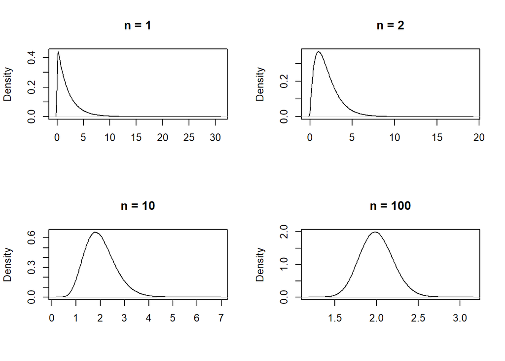

In the special case that each $X_i$ is Normal, then Definition 8.2 is true for any value of $n$ (not necessarily large).

**Example 8.1** Suppose that each week, the number of calls to a taxi firm has a Poisson distribution with rate parameter 100. Use the central limit theorem to estimate the probability that the total number of calls in one year is no more than $5000$.

Solution:

Let $X_i$ be the number of calls in week $i$. Then $X_1,X_2,\ldots,X_{52}$ is a sequence of IID Poisson RVs, each with rate parameter $100$. We therefore have $\mu=E(X_i)=100$ and $\sigma^2=Var(X_i)=100$. We are interested in the total (not average) in a year $\sum_{i=1}^{52}X_i$.

By the second form of the CLT we know
$$\sum^{52}_{i=1}X_i\sim N\left(52\times100,52\times100\right)=N(5200,5200).$$

We evaluate this using the MatLab command `normcdf(5000.5,5200,72.1)` = 0.00283.

Note: we make the slight adjustment of 5000 to 5000.5 to reflect the fact that the number of calls must be integer, but we are approximating by a continuous distribution.

# 9 Introductory Statistics, Inference, Estimation & Quantifying Uncertainty

## 9.1 Introduction

In statistics we use data to tell us about things that we don’t know (but want to know about). It usually involves some form of random sampling which means we need to use ideas from probability theory to quantify the uncertainty of any estimates we derive. There are three (inter-related) major strands:

1. Survey/experiment design & data collection.
2. Manipulating, storing & summarising data.
3. Using the data to make inferences about quantities of interest.

We will say little about strand (1), except that if your data collection strategy is poor, your data will not be very informative and may lead to the wrong conclusions. E.g. if we are interested in the average height of undergraduate students in Sheffield, but only sample women’s heights we will probably get an underestimate of the true value.

You will already be familiar with some aspects of strand (2), for example, simple numerical summaries like the mean and range of a set of numbers and graphical aids like histograms and scatter plots. We will recap on a few of the most important numerical summaries below. This strand extends to topics like multivariate exploratory data analysis where we can look for patterns in huge, complex data sets. It also includes important topics at the interface of Statistics and Computer Science like data security, error detection and efficient algorithms for searching and sorting large data sets.

We will concentrate on strand (3), which itself has two main subbranches: estimation and testing.

## 9.2 Notation

Here we distinguish between RVs and observations. We use upper case $X_i$ to denote a RV which could follow some suitable probability distribution, such as $X_i\sim N(\mu,\sigma^2)$. The lower case notation $x_i$ represents an **observed value** and therefore is a number and could **not** follow a probability distribution.

The following examples explain why the distinction is important:

1. Suppose we are going to roll a 6-sided die $n$ times. Let $X_i$ be the outcome of the $i$-th roll of the die. We don’t yet know what the outcomes are, so $X_1,...,X_n$ are thought of as RVs, and we can, for example, make statements such as $P(X_i=2)=\frac{1}{6}$
2. After we roll the die $n$ times, we denote the numbers we actually observe as $x_1,...,x_n$. For example, if we see a $4$ on the $i$-th roll, we would write $x_i=4$ (**not** $X_i = 4$).
3. Any expression involving $X_1,...,X_n$ corresponds to the time **before** we have observed the data. Each $X_i$ is a RV.
4. Any expression involving $x_1,...,x_n$ corresponds to the time **after** we have observed the data. The $x_i$ values are just the outcomes of the experiment (they are not RVs).

## 9.3 Numerical Summaries

Suppose we have a collection of IID RVs $X_1, X_2, \ldots, X_n$ with $E(X_i)= \mu$ and $\text{var}(X_i)=\sigma^2$ (both unknown). We do an experiment and observe the values of $x_1,...,x_n$. How do summarise the data?

### 9.3.1 Sample Mean

**Definition 9.1** Given the observations $x_1,x_2,...,x_n$, we define the sample mean to be
$$\bar x = \frac{1}{n}\sum^n_{i=1}x_i.$$

Note that **before** we collect any data the RV
$$\label{Xbar} \bar{X}=\frac{1}{n}\sum^n_{i=1}X_i$$
is effectively a ‘formula’ for calculating the sample mean from the IID RVs $X_1, X_2, \ldots, X_n$. You should not confuse $\bar x$ or $\bar X$ with $\mu$. The difference between these three ‘means’ is very important.

### 9.3.2 Sample Variance

**Definition 9.2** Given the observations $x_1,x_2,...,x_n$, we define the **sample variance** to be
$$s^2 = \frac{1}{n-1}\sum^n_{i=1}(x_i-\bar x)^2=\frac{1}{n-1}\left(\sum^n_{i=1}x_i^2-n\bar x^2\right).$$

Again **before** we collect any data the RV
$$S^2=\frac{1}{n-1}\sum^n_{i=1}(X_i-\bar X)^2=\frac{1}{n-1}\left(\sum^n_{i=1}X_i^2-n\bar X^2\right)$$
is effectively a ‘formula’ for calculating the sample variance. You should not confuse $s^2$ or $S^2$ with $\sigma^2$.

The use of $n-1$ in the denominator is a little surprising (intuitively $n$ would make more sense). The use of $n-1$ results in $S^2$ being an ‘unbiased estimator’ of $\sigma^2$.

### 9.3.3 Sample Correlation

Given the observations $(x_1,y_1)$, $(x_2,y_2)$, ..., $(x_n,y_n)$ we define the sample correlation coefficient (sometimes called Pearson’s correlation coefficient) to be
$$r=\frac{\sum(x_i-\bar x)(y_i-\bar y)}{\sqrt{\sum(x_i-\bar x)^2\sum(y_i-\bar y)^2}}=\frac{\sum x_iy_i-n\bar x\bar y}{\sqrt{(\sum x_i^2-n\bar x^2)(\sum y_i^2-n\bar y^2)}}.$$
Note that:

1. $-1\leq r \leq 1$.
2. $r$ measures **linear** correlation. $|r|$ is close to $1$ when the $(x_i,y_i)$ pairs are close to a straight line on a scatter plot. If they are strongly related, but in a **non-linear** way, $r$ can be close to $0$.

**Example 9.1** We collected data from eight female students on their height in centimeters, these are given below:
$$160\text{, } 165\text{, } 180\text{, } 157\text{, } 172\text{, } 175\text{, } 145\text{, } 152$$
calculate the mean and variance of the sample.

Solution:

$$\bar x=163.25cm$$
$$s^2=\frac{1}{7}\left(214212-8\times163.25^2\right)=143.93cm^2.$$

## 9.4 Inference

In statistical inference, we use information from a suitable sample to draw conclusions about a much larger population of interest which cannot be examined in its entirety. In many cases, the Central Limit Theorem (CLT) in Definition 8.2 plays a key role. For example if $X_1, X_2, \ldots, X_n$ are IID RVs we can see that $\bar X$ in Equation (8.1) will be normal if $n$ is large enough (by the CLT). The distribution of $\bar X$ is called the **sampling distribution** and tells us how far away from $\mu$ the sample mean is likely to be. In this case we use $\bar x$ as the estimate of $\mu$.

## 9.5 Estimation

Our objective here is to find a sensible estimate of the parameters of a probability distribution.

### 9.5.1 Terminology and Notation

An **estimator** is some function of RVs (typically IID $X_1, X_2, \ldots, X_n$) which we use to estimate some parameter. Its actual numerical value is called the **estimate**.

**Example 9.2** Suppose a RV $X$ representing some interesting feature about a population is believed to follow an Exp$(\lambda)$ distribution. Suppose we sample $n$ values of $X$ ($X_1, X_2, \ldots, X_n$). Assuming that $X_1, X_2, \ldots, X_n$ are independent we have $n$ IID RVs each with an Exp$(\lambda)$ distribution. Recall from Definition 6.7 that $E(X_i)=1/\lambda$ and Var$(X_i)=1/\lambda^2$. The CLT (Definition 8.2) states that
$$\bar X \sim N\left(\frac{1}{\lambda},\frac{1}{n\lambda^2}\right).$$
This result implies a potential estimator of $\lambda$ could be the reciprocal of the sample mean. We write this as
$$\begin{align}
\hat\lambda &= \frac{1}{\bar X} \\
&= \frac{n}{X_1 + X_2 + \ldots + X_n}.
\end{align}$$
and once we have observed $x_1,x_2,...,x_n$ the actual numerical **estimate** is
$$\hat\lambda=\frac{1}{\bar x}.$$
Suppose we sample 100 values from the population and observe a sample mean of 12.6 then our estimate of $\lambda$ is $\hat\lambda = 1/12.6 = 0.08$

Note that we put a ‘hat’ over the parameter being estimated to denote that it is an estimator. So $\hat \lambda$ is an estimator of $\lambda$.

### 9.5.2 Methods of Estimation

The approach in Example 9.2 is sensible but restricted to certain situations. We need a well defined procedure to use in all cases. There are two common estimation methods: **least squares** and **maximum likelihood**.

Least squares estimation is useful because it **does not** make any assumptions about the probability**distribution** of the RVs, only about their expectations. Maximum likelihood estimation**does** require a probability distribution to be specified, but has the advantage that we can assess how close our estimates are likely to be to their target. For this reason, maximum likelihood is the most commonly used estimation method. We do not either estimation method here but Least Squares estimation is covered next semester.

### 9.5.3 Unbiased Estimators

A desirable property of an estimator is that it should be unbiased. For an estimator $\hat\theta$ of a parameter $\theta$ we define the bias as
$$\text{bias}=E\left(\hat\theta\right)-\theta$$
If $E\left(\hat\theta\right)=\theta$ then the bias is 0 and ‘on average’ the estimator gives the correct value. Estimators with zero bias are called **unbiased** estimators.

**Example 9.3** Suppose $X_1, X_2, \ldots, X_n$ are $n$ IID RVs each with $E(X_i)= \mu$. Then
$$\hat \mu = \frac{1}{n}\sum^n_{i=1}X_i$$
is an unbiased estimator of $\mu$. To verify this we need to show that $E(\hat \mu) = \mu$.
$$\begin{align}
E(\hat \mu) &= E\left( \frac{1}{n}\sum^n_{i=1}X_i\right) \\
&= \frac{1}{n} \sum^n_{i=1}E(X_i) \\
&= \mu \; \text{since} \; E(X_i)=\mu
\end{align}$$
Hence $\hat \mu$ is an unbiased estimator of $\mu$.

## 9.6 Confidence intervals

A single best guess at a parameter value $\theta$ is of some use but we also need to give an idea of our uncertainty in the estimate. We usually do this by providing an interval in which $\theta$ is likely to lie, with some level of certainty.

To specify a confidence interval (CI) we first need to decide on a **confidence level** which is usually expressed as a percentage and is typically 95%. Confidence levels are often misinterpreted. It is incorrect to say that the interval contains the true parameter value with 95% probability (it either contains it or it doesn’t). Instead you should make statements about the process that generates them. It is correct to say that 95% of intervals constructed in this way are expected to contain the true parameter value.

We now identify the $\alpha$ level associated with our confidence level. Let $c$ be the confidence level expressed as a decimal, then
$$\alpha ~=~ 1-c$$
eg 95% is associated with $\alpha=0.05$. We use this $\alpha$ to specify quantiles for calculation of the CIs.

### 9.6.1 CI for mean of Normal data, $\sigma^2$ known

Let $X_1,X_2,...,X_n$ be a random sample from a normal distribution $N(\mu,\sigma^2)$ with unknown $\mu$ and known $\sigma^2$. $X_1,X_2,...,X_n$ are therefore IID RVs with $E(X_i) = \mu$.

A $100(1-\alpha)$% confidence interval for $\mu$ is centred at $\bar X$ and is given by
$$\left(\bar X-z_{1-\frac{\alpha}{2}}\frac{\sigma}{\sqrt{n}},\bar X+z_{1-\frac{\alpha}{2}}\frac{\sigma}{\sqrt{n}}\right)$$
often written as
$$\bar X\pm z_{1-\frac{\alpha}{2}}\frac{\sigma}{\sqrt{n}}$$
where $z_{1-\frac{\alpha}{2}}$ solves $\Phi\left(z_{1-\frac{\alpha}{2}}\right)=1-\frac{\alpha}{2}$ and is evaluated using MatLab’s quantile function `norminv`$(1-\frac{\alpha}{2},0,1)$. Remember that at this stage, before collecting any data, $\bar X$ is a RV.

**Example 9.4** Components are produced from a machine with standard deviation $0.08$kg and are supposed to have mean weight $0.6$kg. A sample of $30$ components has an average weight of $0.63$kg. Calculate a $95\%$ confidence level for $\mu$ and comment on whether the machine should be repaired.

Solution:

We have $\overline{x} = 0.63, \sigma = 0.08$ and $n = 30$. For $95\%$ we use $\alpha = 0.05$ and $z_{1-\frac{\alpha}{2}} = 1.96$. The confidence interval is therefore
$$\begin{align}
\overline{x} \pm z_{1-\frac{\alpha}{2}}\frac{\sigma}{\sqrt{n}} &= 0.63 \pm 1.96 \times \frac{0.08}{\sqrt{30}}\\
&= 0.63 \pm 0.0286\\
&= (0.6014,0.6586)
\end{align}$$
There is therefore good evidence that the machine is faulty as the intended mean $0.6$ lies outside the confidence interval.

### 9.6.2 CI for mean of Normal data, $\sigma^2$ unknown

If we don’t know $\sigma^2$ we estimate it from the data by $S^2$, but then we must modify our sampling distribution. It is no longer a normal distribution but is now has a **Student $t$ distribution** with $n-1$ **degrees of freedom** (where $n$ is the number of data points used to construct the interval). You don’t need to know why this is true.

The $t$ distribution is a distribution similar to $N(0,1)$ symmetric about $0$, but lower it has fatter tails especially for small $n$. You can calculate $t$ quantiles in MatLab with $tinv(p,\nu)$ where $p$ is the probability $\left(1-\frac{\alpha}{2}\right)$ and $\nu$ is the degrees of freedom.

A $100(1-\alpha)$% confidence interval for $\mu$ is given by
$$\overline{X} \pm t_{1-\frac{\alpha}{2}}\frac{S}{\sqrt{n}}$$
where $S$ is the sample standard deviation.

**Example 9.5** Suppose we have the scenario of Example 9.4, but regard the standard deviation as unknown. If we estimate it by the sample standard deviation of $0.078$kg, calculate an appropriate CI for $\mu$ and comment on how it differs from the previous CI.

Solution:

We have $\overline{x} = 0.63, s = 0.078$ and $n = 30$. For $95\%$ we use $\alpha = 0.05$ and $t_{1-\frac{\alpha}{2}} = 2.0452$ using `tinv(0.975,29)`.

The confidence interval is therefore
$$\begin{align}
\overline{x} \pm t_{1-\frac{\alpha}{2}}\frac{s}{\sqrt{n}} &= 0.63 \pm 2.0452 \times \frac{0.078}{\sqrt{30}}\\
&= 0.63 \pm 0.0291\\
&= (0.6009,0.6591)
\end{align}$$
This is slightly wider than before, even with a smaller standard deviation, because we have extra uncertainty in our estimation because $\sigma^2$ is unknown.

# 10 Hypothesis Testing

In hypothesis testing we try and assess what evidence the data provide regarding the plausibility of various hypotheses.

Hypotheses can be of many types; we will only cover two of these:

- A parameter takes a specified value, e.g. $H_0:\mu=2$.
- A particular probability model is applicable (the “goodness of fit” problem), e.g. $H_0$: accident counts follow a Poisson distribution.

## 10.1 Test procedure

As before we assume that we have a random sample of data which we consider to be IID RVs.

The null hypothesis $H_0$ reflects what we will continue to believe unless the data suggests otherwise. We then specify an **alternative** hypothesis (usually the complement of $H_0$) and denote it $H_1$ (or $H_A$).

Next we define the **test statistic**. This is a function of the data that measures how much it ‘disagrees with’ $H_0$. The test statistic will have a known sampling distribution (called the **null sampling distribution**) under the assumption that $H_0$ is true . We then check whether our observed test statistic looks consistent with the null sampling distribution or not. Essentially this means looking to see whether the observed test statistic is near the middle of the null sampling distribution or in the tails.

To decide whether the observed test statistic is consistent with $H_0$, we have to state how small aprobability is surprising (our **significance level**). Typically this is (arbitrarily) set at 5% but other values are sometimes used (e.g. 10% or 1%). We then identify the quantiles of the null sampling distribution that correspond to this probability and then check our observed test statistics against these quantiles. We illustrate the procedure with some examples.

## 10.2 One sample $z$ tests

Assume that our IID RVs (sampled data) follow a $N(\mu ,\sigma^2)$ distribution with $\sigma^2$ known. We are interested in testing a null hypothesis
$$H_0: \mu=\mu_0$$
we use a **one sample $z$ test**. Our test statistic is
$$Z=\frac{\bar X - \mu_0}{\sigma/\sqrt{n}}$$
which has a null sampling distribution $Z \sim N(0,1)$. Recall the $2\sigma$-rule reproduced in Figure 10.1.

[figure not shown]

Figure 10.1: The PDF of a $N(0,1)$ random variable. The unshaded area is 0.95

If $Z\sim N(0,1)$, then $P(-1.96\leq Z\leq1.96)=0.95$, so there is a 5% chance that either $Z<-1.96$ or $Z>1.96$. If the test statistic has an **absolute value** greater than 1.96 then it is in the tails of the null sampling distribution (at the 5% level) and we would reject $H_0$ at this level. Take care when calculating your quantiles; for a combined 5% probability in both tails, you look up the value giving $2.5$% in each tail for example *norminv*$(0.975,0,1)$. It is common to approximate 1.96 by 2.

**Example 10.1** The volume of liquid in cartons produced by a particular machine is modelled as a $N(\mu, 6^2)$ distribution. A sample of $30$ cartons from this machine gives an average volume of $566$ ml. Test the hypothesis that the mean amount of fluid is $568$ ml at the $10\%$ level.

Solution:

Our null and alternative hypotheses

- $H_0: \mu = 568$,
- $H_1: \mu \neq 568$.

We can now calculate our test statistic to be
$$z =\displaystyle \frac{\overline{x} - \mu_0}{\frac{\sigma}{\sqrt{n}}} = \frac{566 - 568}{\frac{6}{\sqrt{30}}} = -1.83.$$
We compare the absolute value of the test statistic to the 0.95 quantile of the standard normal distribution. $z_{0.95} = 1.645$ and since $|-1.83| > 1.645$ we have **sufficient evidence** to reject $H_0$ at the 10% level.

## 10.3 One sample $t$ tests

As in Section 9.6.2, if we **do not know** $\sigma^2$ and have to estimate it from the data by the sample variance $S^2$. Our test statistic is
$$T=\frac{\bar X - \mu_0}{s/\sqrt{n}}$$
The sampling distribution of T under the null hypothesis is now the $t_{n-1}$ distribution so we use $t$ rather than $z$ quantiles. The procedure is otherwise the same. This is called the **one-sample** $t$ test.

**Example 10.2** The volume of liquid in cartons produced by a particular machine is modelled as a $N(\mu, \sigma^2)$ distribution where $\sigma^2$ is unknown. A sample of $30$ cartons from this machine gives an average volume of $566$ ml and a sample standard deviation of 5.75 ml. Test the hypothesis that the mean amount of fluid is $564$ ml at the $5\%$ level.

Solution:

We can now calculate our test statistic to be
$$t =\displaystyle \frac{\overline{x} - \mu_0}{\frac{s}{\sqrt{n}}} = \frac{566 - 564}{\frac{5.75}{\sqrt{30}}} = 1.91.$$
The 0.975 quantile of a $t_{29}$ distribution is 2.04 so since $|1.91| < |2.04|$ we have **insufficient evidence** to reject $H_0$ at this level.

## 10.4 Using confidence intervals to perform tests

Because test statistics and confidence intervals are constructed in very similar ways, we can use a 95% confidence interval to perform a test at the 5% level or and a 90% confidence interval to perform a test at the 10% level. The test is performed by checking whether the hypothesized value is contained within the interval or not. If it is in the interval then it is consistent with the null hypothesis and there isn’t sufficient evidence to reject the null hypothesis.

**Example 10.3** The log of the current (in amps) in a circuit is modelled as a $N(\mu, 1)$ distribution. A random sample of $9$ currents at different times gives a mean of $2.40$ amps. Calculate a 95 precent confidence interval for $\mu$ and hence test, at the $5\%$ level, the hypothesis that the mean current is $3.50$ amps.

Solution:

Because $\sigma$ is known, the 95% confidence interval is
$$\begin{align}
\overline{x} \pm z_{1-\frac{\alpha}{2}}\frac{\sigma}{\sqrt{n}} &= 2.40 \pm 1.96 \times \frac{1}{\sqrt{9}}\\
&= 2.40 \pm 0.65\\
&= (1.75,3.05)
\end{align}$$
Our null and alternative hypotheses

- $H_0: \mu = 3.5$ amps,
- $H_1: \mu \neq 3.5$ amps.

Because 3.5 ($\mu$) **is not** in the 95 percent confidence interval we have **sufficient evidence** to reject $H_0$ at the 5% level.

## 10.5 Goodness of fit tests

Consider the number of lorries arriving at a warehouse in hourly intervals. Is it plausible that the number of arrivals follows a Poisson distribution?

| no. of arrivals per hour | 0 | 1 | 2 | 3 | 4 | 5 | 6 | 7 |
| --- | --- | --- | --- | --- | --- | --- | --- | --- |
| no. of hours | 53 | 152 | 130 | 102 | 44 | 11 | 5 | 3 |

The general principle is to compare our **observed** table of counts, with what we would **expect**, if the null hypothesis is true. Define $o_j$ and $e_j$ to be the observed and expected count in cell $j$ of the table respectively. The test statistic is
$$\sum_{\text{all cells}}\frac{(o_j-e_j)^2}{e_j}.$$

Its null sampling distribution is a **chi squared distributions**, written $\chi^2$. This is another family of distributions, indexed by a `degrees of freedom` parameter $\nu$. It is not symmetric unlike the $t$ or normal distribution (See Figure 10.2. To perform the test you need to calculate the expected counts in each cell, specify $\nu$ and calculate the relevant quantiles from the $\chi^2$ distribution.

[figure not shown]

Figure 10.2: A chi-squared distribution with 4 degrees of freedom.

We use the multinomial distribution (Section 5.3) to say how many observations of a particular type we would expect. We demonstrate this in Example 10.4.

**Example 10.4** The numbers of lorries arriving at a warehouse in a given hour is expected to follow a *Poisson distribution*. The probability that $k$ trucks arrive in an hour is $\frac{\lambda^ke^{-\lambda}}{k!}$ for some $\lambda$. The number of lorries arriving was counted over 500 separate hours with the following results:

| no. of arrivals per hour | 0 | 1 | 2 | 3 | 4 | 5 | 6 | 7 |
| --- | --- | --- | --- | --- | --- | --- | --- | --- |
| no. of hours | 53 | 152 | 130 | 102 | 44 | 11 | 5 | 3 |

Test the hypothesis that the arrivals are distributed in a Poisson distribution.

Solution:

The total number of lorries arriving in the 500 hours is 1000. Therefore the mean number per hour is 2 and so we infer that $\lambda=2$.

[Check: $0 \times 53 + 1 \times 152 + ...+7 \times 3 =1000]$

Using the Po$(2)$, we can calculate the expected number of hours where there should be no arrivals. $P(0)=\frac{2^0e^{-2}}{0!}=e^{-2}=0.135$, and since there are 500 hours sampled, we expect 67.7 hours where there should be no arrivals.

Similarly, the number of hours with $1$ arrival is $\frac{2^1e^{-2}}{1!}=2e^{-2}=0.271$ hence we expect $135.3$ hours with one arrival etc. Hence

| $j$ | 0 | 1 | 2 | 3 | 4 | 5 | 6 | 7 |
| --- | --- | --- | --- | --- | --- | --- | --- | --- |
| $o_j$ | 53 | 152 | 130 | 102 | 44 | 11 | 5 | 3 |
| $e_j$ | 67.7 | 135.3 | 135.3 | 90.2 | 45.1 | 18.0 | 6.0 | 2.3 |

The $e_j$ do **not** need to be integers though the observed counts obviously are.

In this example there are never more than 7 lorries arriving in any hour but there could be. To allow for all possibilities we should really change the final cell to $\geq 7$. We then calculate $e_j$ by first finding $P(X\geq 7)$. We do need to make the assumption $X=7$ exactly in order to infer $\lambda=2$.

The value of the test statistic is $\sum^{7}_{j=0}\frac{\left(o_j-e_j\right)^2}{e_j}=10.13$.

The degrees of freedom are given by $\nu=n-r-1$ where $n$ is the number of cells and $r$ is the number of parameters we have inferred (here just $\lambda$). This gives $\nu=8-1-1=6$.

At the 5% level of test, the 0.95 quantile can be calculated using chi2inv$(0.95,6)=12.59$ in Matlab. Since $10.13<12.59$ we have **insufficient evidence** at the 5 percent level to reject the null hypothesis that a Poisson probability model is a suitable model for the number of arrivals per hour at the warehouse. In other words, the $Poisson(2)$ distribution is a plausible model for these data. Note that when finding quantiles using the $\chi^2$ distribution we don`t split the probability between the two tails as we do for the normal and $t$ distributions.